# Desafios e Requisitos dos Projetos Analíticos

Julho de 2021

Turma: **FGV TBABD-8**  
Professor: **Rafael Lychowski**  
Autores: **Davi Almeida Ferreira**,  
**Guilherme Rocha Gomez** e  
**Juscelino Ribeiro Carvalho**

## Metodologia utilizada

Utilizaremos para a realização deste trabalho a metodologia CRISP-DM

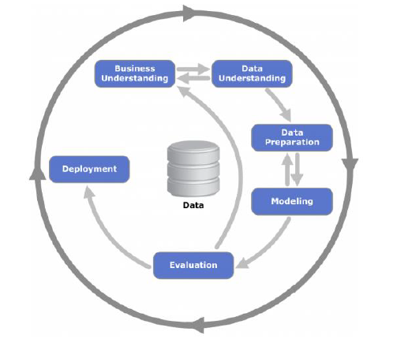

## Entendimento do Negócio

A Vale pretende prever o desgaste de rodas de vagões e fornecer uma visão futura da frota de rodeiros, para melhor planejamento de manutenção e compra de componentes.

**Problema:** Prever se o friso da roda está abaixo de 26 mm na próxima leitura.

1. A área não tem visibilidade do que vai acontecer com os ativos, antecipando as trocas;
2. A cada troca o rodeiro é usinado, e sua vida útil reduzida;
3. Incapacidade de visualização de desgastes acelerados em toda a frota de vagões
4. Muitos vagões apresentam reincidência de trocas, e os fatores não são bem claros;
- Base de dados: EFC_WAYSIDES.csv
- Variável dependente: ESPESSURA_FRISO_RODA
- Método: Supervisionado
- Submétodo: Classificação
- Objetivo: Identificar quais os frisos terão menos que 26 cm de friso no próximo ciclo.

## Entendimento dos Dados

### Verificação da qualidade dos Dados

Verificando o ‘Schema’ dos dados

```r
#Verificando o 'Schema' dos dados"
printSchema(df)
```

```
## root
##  |-- ROW_ID: string (nullable = true)
##  |-- DATA_HORA_LEITURA: timestamp (nullable = true)
##  |-- CODIGO_VAGAO: string (nullable = true)
##  |-- CODIGO_RODEIRO: string (nullable = true)
##  |-- CODIGO_RODA: string (nullable = true)
##  |-- LADO_RODA: string (nullable = true)
##  |-- EIXO_VAGAO: integer (nullable = true)
##  |-- CICLO_RODEIRO: string (nullable = true)
##  |-- TRAIN_ID: string (nullable = true)
##  |-- SENTIDO_TREM: string (nullable = true)
##  |-- VELOCIDADE_ENTRADA_TREM: double (nullable = true)
##  |-- VELOCIDADE_SAIDA_TREM: double (nullable = true)
##  |-- POSICAO_VAGAO_COMPOSICAO: integer (nullable = true)
##  |-- ANGULO_FRISO_RODA: double (nullable = true)
##  |-- ALTURA_FRISO_RODA: double (nullable = true)
##  |-- ESPESSURA_FRISO_RODA: double (nullable = true)
##  |-- CAVA_RODA: double (nullable = true)
##  |-- ANGULO_ATAQUE_EIXO_FRONTAL_TRUQUE: double (nullable = true)
##  |-- ANGULO_ATAQUE_EIXO_TRASEIRO_TRUQUE: double (nullable = true)
##  |-- TRACKING_POSITION_EIXO_FRONTAL_TRUQUE: double (nullable = true)
##  |-- TRACKING_POSITION_EIXO_TRASEIRO_TRUQUE: double (nullable = true)
##  |-- ROTACAO_EIXO: double (nullable = true)
##  |-- ALINHAMENTO_ENTRE_EIXOS_IAM: double (nullable = true)
##  |-- DESLOCAMENTO_ENTRE_EIXOS_SHIFT: double (nullable = true)
##  |-- TRACKING_ERROR_TE: double (nullable = true)
##  |-- SERPENTEAMENTO_HUNTING: double (nullable = true)
##  |-- FRISO_BAIXO: double (nullable = false)
##  |-- FRISO_MENOR_QUE_26: string (nullable = false)
##  |-- DIA: date (nullable = true)
```

Foram criadas as seguintes variáveis:

**FRISO_BAIXO**: Indica com 1 ou 0 se a ESPESSURA_FRISO_RODA é maior ou menor que 26 mm. Utilizada como variável DEPENDENTE nos modelos.  
**FRISO_MENOR_QUE_26**: Indica com YES ou NO se a ESPESSURA_FRISO_RODA é maior ou menor que 26 mm. Utilizada para análise exploratória.  
**DIA**: Indica o dia (ANO/MÊS/DIA) da ocorrência do dado. Utilizada para análise exploratória e para ordenar o modelo.

### Verificar a existência de dados faltantes

Verificamos a concentração de dados nulos nas variáveis CAVA_RODA, ANGULO_FRISO_RODA e nas geradas pelo TBOGIE.

```r
#Verificando qualidade dos dados.

test_null <- function(data_frame,coluna){
   try(data_frame %>% where(.,isNull(.[[coluna]]))%>%count(.), silent = TRUE)}

test_isNAN <- function(data_frame,coluna){
  try(data_frame %>% where(.,isNaN(.[[coluna]]))%>%count(.), silent = TRUE)}

test_vazio <- function(data_frame,coluna){
  try(data_frame %>% where(.,.[[coluna]]== "")  %>% count(.), silent = TRUE)}

test_zero <- function(data_frame,coluna){
  try(data_frame %>% where(.,.[[coluna]]== 0)  %>% count(.), silent = TRUE)}

total <- count(df)

#class(df$ROW_ID)

x <- 0
Tipo_de_dados <- 0

# Criando a coluna de tipo de dados
for (i in 1:length(colnames(df))){
  x[i] <- dtypes(df)[[i]][1]
  Tipo_de_dados[i] <- dtypes(df)[[i]][2]
}
tipo_dados <- as.data.frame(Tipo_de_dados,x)

cont_prob <- data.frame()
for (coluna in colnames(df)){
#As colunas no dataframe serão linhas neste relatório.

  cont_prob[coluna,"Nulo"] <- test_null(df,coluna)
  cont_prob[coluna,"Nulo"] <- ifelse(is.numeric(cont_prob[coluna,"Nulo"]),
                                      cont_prob[coluna,"Nulo"], 0)
  cont_prob[coluna,"% Nulo"]  <- ifelse(is.numeric(cont_prob[coluna,"Nulo"]), paste(round(((cont_prob[coluna,"Nulo"]/total)*100),2),"%",sep=""), "0%")

  cont_prob[coluna,"isNAN"] <- test_isNAN(df,coluna)
  cont_prob[coluna,"isNAN"] <- ifelse(is.numeric(cont_prob[coluna,"isNAN"]),
                                      cont_prob[coluna,"isNAN"], 0)
  cont_prob[coluna,"% isNAN"] <- ifelse(is.numeric(cont_prob[coluna,"isNAN"]), paste(round(((cont_prob[coluna,"isNAN"]/total)*100),2),"%",sep=""), "0%")

  cont_prob[coluna,"Vazio"] <- test_vazio(df,coluna)
  cont_prob[coluna,"Vazio"] <- ifelse(is.numeric(cont_prob[coluna,"Vazio"]),
                                      cont_prob[coluna,"Vazio"], 0)

  cont_prob[coluna,"% Vazio"] <- ifelse(is.numeric(cont_prob[coluna,"Vazio"]), paste(round(((cont_prob[coluna,"Vazio"]/total)*100),2),"%",sep=""), "0%")

  cont_prob[coluna,"Zero"]  <- test_zero(df,coluna)
  cont_prob[coluna,"Zero"]  <- ifelse(is.numeric(cont_prob[coluna,"Zero"]),
                                      cont_prob[coluna,"Zero"],0)

  cont_prob[coluna,"% Zero"] <- ifelse(is.numeric(cont_prob[coluna,"Zero"]), paste(round(((cont_prob[coluna,"Zero"]/total)*100),2),"%",sep=""), "0%")

}

cont_prob <- cbind(cont_prob,tipo_dados)

cont_prob %>% kable(., format = "html",row.names = T, digits = 2) %>%
  kable_styling(bootstrap_options = c("striped","hover","condensed","responsive"))
```

|  | Nulo | % Nulo | isNAN | % isNAN | Vazio | % Vazio | Zero | % Zero | Tipo_de_dados |
| --- | --- | --- | --- | --- | --- | --- | --- | --- | --- |
| ROW_ID | 0 | 0% | 0 | 0% | 0 | 0% | 0 | 0% | string |
| DATA_HORA_LEITURA | 0 | 0% | 0 | 0% | 0 | 0% | 0 | 0% | timestamp |
| CODIGO_VAGAO | 0 | 0% | 0 | 0% | 0 | 0% | 0 | 0% | string |
| CODIGO_RODEIRO | 0 | 0% | 0 | 0% | 0 | 0% | 0 | 0% | string |
| CODIGO_RODA | 0 | 0% | 0 | 0% | 0 | 0% | 0 | 0% | string |
| LADO_RODA | 0 | 0% | 0 | 0% | 0 | 0% | 0 | 0% | string |
| EIXO_VAGAO | 0 | 0% | 0 | 0% | 0 | 0% | 0 | 0% | int |
| CICLO_RODEIRO | 0 | 0% | 0 | 0% | 0 | 0% | 0 | 0% | string |
| TRAIN_ID | 0 | 0% | 0 | 0% | 0 | 0% | 0 | 0% | string |
| SENTIDO_TREM | 0 | 0% | 0 | 0% | 0 | 0% | 0 | 0% | string |
| VELOCIDADE_ENTRADA_TREM | 0 | 0% | 0 | 0% | 0 | 0% | 0 | 0% | double |
| VELOCIDADE_SAIDA_TREM | 0 | 0% | 0 | 0% | 0 | 0% | 0 | 0% | double |
| POSICAO_VAGAO_COMPOSICAO | 0 | 0% | 0 | 0% | 0 | 0% | 0 | 0% | int |
| ANGULO_FRISO_RODA | 287408 | 9.69% | 0 | 0% | 0 | 0% | 0 | 0% | double |
| ALTURA_FRISO_RODA | 2354 | 0.08% | 0 | 0% | 0 | 0% | 0 | 0% | double |
| ESPESSURA_FRISO_RODA | 11146 | 0.38% | 0 | 0% | 0 | 0% | 0 | 0% | double |
| CAVA_RODA | 607049 | 20.46% | 0 | 0% | 0 | 0% | 0 | 0% | double |
| ANGULO_ATAQUE_EIXO_FRONTAL_TRUQUE | 19723 | 0.66% | 0 | 0% | 0 | 0% | 0 | 0% | double |
| ANGULO_ATAQUE_EIXO_TRASEIRO_TRUQUE | 19723 | 0.66% | 0 | 0% | 0 | 0% | 0 | 0% | double |
| TRACKING_POSITION_EIXO_FRONTAL_TRUQUE | 19723 | 0.66% | 0 | 0% | 0 | 0% | 0 | 0% | double |
| TRACKING_POSITION_EIXO_TRASEIRO_TRUQUE | 19723 | 0.66% | 0 | 0% | 0 | 0% | 0 | 0% | double |
| ROTACAO_EIXO | 19723 | 0.66% | 0 | 0% | 0 | 0% | 0 | 0% | double |
| ALINHAMENTO_ENTRE_EIXOS_IAM | 19731 | 0.67% | 0 | 0% | 0 | 0% | 0 | 0% | double |
| DESLOCAMENTO_ENTRE_EIXOS_SHIFT | 19731 | 0.67% | 0 | 0% | 0 | 0% | 0 | 0% | double |
| TRACKING_ERROR_TE | 19763 | 0.67% | 0 | 0% | 0 | 0% | 0 | 0% | double |
| SERPENTEAMENTO_HUNTING | 18143 | 0.61% | 0 | 0% | 0 | 0% | 0 | 0% | double |
| FRISO_BAIXO | 0 | 0% | 0 | 0% | 0 | 0% | 0 | 0% | double |
| FRISO_MENOR_QUE_26 | 0 | 0% | 0 | 0% | 0 | 0% | 0 | 0% | string |
| DIA | 0 | 0% | 0 | 0% | 0 | 0% | 0 | 0% | date |

### Avaliando os dados nulos

Avaliando a ocorrência de dados nulos de CAVA_RODA e ANGULO_FRiSO_RODA

CAVA_RODA: A variável com maior número de dados nulos foi a CAVA_RODA com 607.049 (20%) de dados nulos.

ANGULO_FRISO_RODA: A segunda variável com maior número de dados nulos foi a ANGULO_FRISO_RODA com 287.408 (10%) dados nulos em comparação as outras variáveis.

Como podemos perceber a ocorrência de dados nulos é distribuída por todo o período de medição sendo que ocorreu uma acentuação nos erros no segundo semestre de 2018. Essa acentuação é proporcional ao aumento do número de dados da amostra que aumentou significativamente no período.

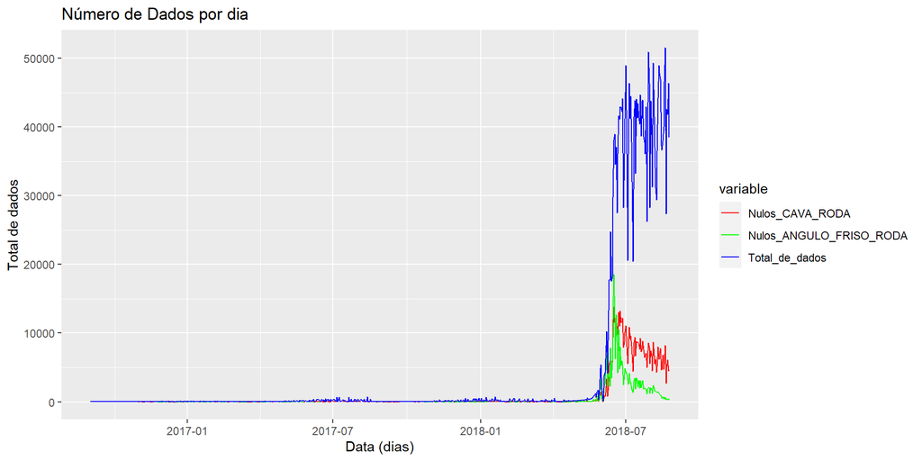

```r
# Avaliando os dados nulos para CAVA_RODA, identificando se ocorreu alguma data com maior numero de dados nulos.

df_null_CAVA_RODA <- where(df, isNull(df$CAVA_RODA))

#perc_nulos_CAVA_RODA

# Avaliando os dados nulos para ANGULO_FRiSO_RODA, indentificando se ocorreu alguma data com maior numero de dados nulos.

df_null_ANGULO_FRISO_RODA <- where(df, isNull(df$ANGULO_FRISO_RODA))

#perc_nulos_ANGULO_FRISO_RODA

# O percentual de dados faltando para CAVA_RODA é de 20%

gb_df_null_CAVA_RODA <- groupBy(df_null_CAVA_RODA, df_null_CAVA_RODA$DIA)

nNull_CAVA_RODA_by_DIA <- agg(gb_df_null_CAVA_RODA, Nulos_CAVA_RODA = n(df_null_CAVA_RODA$Dia))

nNull_CAVA_RODA_by_DIA.dat <- collect(nNull_CAVA_RODA_by_DIA)
#nNull_CAVA_RODA_by_DIA.dat

CAVA_RODA_order_by_date <- nNull_CAVA_RODA_by_DIA.dat[order(nNull_CAVA_RODA_by_DIA.dat$DIA),]
#CAVA_RODA_order_by_date

# O percentual de dados faltando para ANGULO_FRISO_RODA é de 10%

gb_df_null_ANGULO_FRISO_RODA <- groupBy(df_null_ANGULO_FRISO_RODA, df_null_ANGULO_FRISO_RODA$DIA)

nNull_ANGULO_FRISO_RODA_by_DIA <- agg(gb_df_null_ANGULO_FRISO_RODA,
                                      Nulos_ANGULO_FRISO_RODA = n(df_null_ANGULO_FRISO_RODA$Dia))

nNull_ANGULO_FRISO_RODA_by_DIA.dat <- collect(nNull_ANGULO_FRISO_RODA_by_DIA)
#nNull_ANGULO_FRISO_RODA_by_DIA.dat

ANGULO_FRISO_RODA_order_by_date <- nNull_ANGULO_FRISO_RODA_by_DIA.dat[order(nNull_ANGULO_FRISO_RODA_by_DIA.dat$DIA),]
#ANGULO_FRISO_RODA_order_by_date

#Tabela com a contagem de todos os dados
df_order_by_date <-summarize(groupBy(df, df$DIA), Total_de_dados = n(df$ROW_ID))

df_order_by_date <- collect(df_order_by_date)

df_order_by_date <- df_order_by_date[order(df_order_by_date$DIA),]

full <- full_join(CAVA_RODA_order_by_date,
                  ANGULO_FRISO_RODA_order_by_date,
                  by = NULL)

full <- full_join(full,df_order_by_date,
                  by = NULL)

dd = melt(full, id=c("DIA"))

#head(dd)

g_full <-ggplot(dd) + geom_line(aes(x=DIA, y=value, colour=variable)) +
  scale_colour_manual(values=c("red","green","blue"))+
  ggtitle("Número de Dados por dia")+
  xlab("Data (dias)")+
  ylab("Total de dados")
g_full
```

```r
# Gráfico de Full
```

Avaliando as variáveis de TBOGIE  
ANGULO_ATAQUE_EIXO_FRONTAL_TRUQUE, ANGULO_ATAQUE_EIXO_TRASEIRO_TRUQUE, TRACKING_POSITION_EIXO_FRONTAL_TRUQUE.

Essas variáveis apresentam 19.723 de valores nulos, o que equivale a 1% do total dos dados.

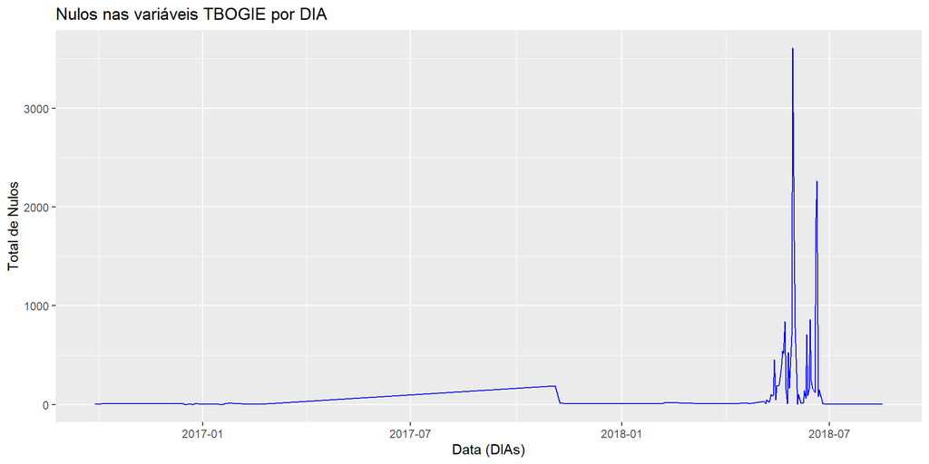

```r
#ANGULO_ATAQUE_EIXO_FRONTAL_TRUQUE
# Avaliando os dados nulos para ANGULO_ATAQUE_EIXO_FRONTAL_TRUQUE, indentificando se ocorreu alguma data com maior numero de dados nulos.

df_null_ANGULO_ATAQUE_EIXO_FRONTAL_TRUQUE <- where(df, isNull(df$ANGULO_ATAQUE_EIXO_FRONTAL_TRUQUE))

nulos_ANGULO_ATAQUE_EIXO_FRONTAL_TRUQUE <- count(df_null_ANGULO_ATAQUE_EIXO_FRONTAL_TRUQUE)

# O percentual de dados faltando para ANGULO_ATAQUE_EIXO_FRONTAL_TRUQUE é de 1%

gb_df_null_ANGULO_ATAQUE_EIXO_FRONTAL_TRUQUE <- groupBy(df_null_ANGULO_ATAQUE_EIXO_FRONTAL_TRUQUE, df_null_ANGULO_ATAQUE_EIXO_FRONTAL_TRUQUE$DIA)

nNull_ANGULO_ATAQUE_EIXO_FRONTAL_TRUQUE_by_DIA <- agg(gb_df_null_ANGULO_ATAQUE_EIXO_FRONTAL_TRUQUE, Nulls_ANGULO_ATAQUE_EIXO_FRONTAL_TRUQUE = n(df_null_ANGULO_ATAQUE_EIXO_FRONTAL_TRUQUE$DIA))

nNull_ANGULO_ATAQUE_EIXO_FRONTAL_TRUQUE_by_DIA.dat <- collect(nNull_ANGULO_ATAQUE_EIXO_FRONTAL_TRUQUE_by_DIA)
#nNull_ANGULO_ATAQUE_EIXO_FRONTAL_TRUQUE_by_DIA.dat

ANGULO_ATAQUE_EIXO_FRONTAL_TRUQUE_order_by_date <- nNull_ANGULO_ATAQUE_EIXO_FRONTAL_TRUQUE_by_DIA.dat[order(nNull_ANGULO_ATAQUE_EIXO_FRONTAL_TRUQUE_by_DIA.dat$DIA),]
#ANGULO_ATAQUE_EIXO_FRONTAL_TRUQUE_order_by_date

# Avaliando os dados nulos para ANGULO_ATAQUE_EIXO_TRASEIRO_TRUQUE, indentificando se ocorreu alguma data com maior numero de dados nulos.

df_null_ANGULO_ATAQUE_EIXO_TRASEIRO_TRUQUE <- where(df, isNull(df$ANGULO_ATAQUE_EIXO_TRASEIRO_TRUQUE))

nulos_ANGULO_ATAQUE_EIXO_TRASEIRO_TRUQUE <- count(df_null_ANGULO_ATAQUE_EIXO_TRASEIRO_TRUQUE)

# O percentual de dados faltando para ANGULO_ATAQUE_EIXO_TRASEIRO_TRUQUE é de 20%

gb_df_null_ANGULO_ATAQUE_EIXO_TRASEIRO_TRUQUE <- groupBy(df_null_ANGULO_ATAQUE_EIXO_TRASEIRO_TRUQUE, df_null_ANGULO_ATAQUE_EIXO_TRASEIRO_TRUQUE$DIA)

nNull_ANGULO_ATAQUE_EIXO_TRASEIRO_TRUQUE_by_DIA <- agg(gb_df_null_ANGULO_ATAQUE_EIXO_TRASEIRO_TRUQUE, Nulls_ANGULO_ATAQUE_EIXO_TRASEIRO_TRUQUE = n(df_null_ANGULO_ATAQUE_EIXO_TRASEIRO_TRUQUE$DIA))

nNull_ANGULO_ATAQUE_EIXO_TRASEIRO_TRUQUE_by_DIA.dat <- collect(nNull_ANGULO_ATAQUE_EIXO_TRASEIRO_TRUQUE_by_DIA)
#nNull_ANGULO_ATAQUE_EIXO_TRASEIRO_TRUQUE_by_DIA.dat

ANGULO_ATAQUE_EIXO_TRASEIRO_TRUQUE_order_by_date <- nNull_ANGULO_ATAQUE_EIXO_TRASEIRO_TRUQUE_by_DIA.dat[order(nNull_ANGULO_ATAQUE_EIXO_TRASEIRO_TRUQUE_by_DIA.dat$DIA),]
#ANGULO_ATAQUE_EIXO_TRASEIRO_TRUQUE_order_by_date

# Avaliando os dados nulos para TRACKING_POSITION_EIXO_FRONTAL_TRUQUE, indentificando se ocorreu alguma data com maior numero de dados nulos.

df_null_TRACKING_POSITION_EIXO_FRONTAL_TRUQUE <- where(df, isNull(df$TRACKING_POSITION_EIXO_FRONTAL_TRUQUE))

# O percentual de dados faltando para TRACKING_POSITION_EIXO_FRONTAL_TRUQUE é de 20%

gb_df_null_TRACKING_POSITION_EIXO_FRONTAL_TRUQUE <- groupBy(df_null_TRACKING_POSITION_EIXO_FRONTAL_TRUQUE, df_null_TRACKING_POSITION_EIXO_FRONTAL_TRUQUE$DIA)

nNull_TRACKING_POSITION_EIXO_FRONTAL_TRUQUE_by_DIA <- agg(gb_df_null_TRACKING_POSITION_EIXO_FRONTAL_TRUQUE, Nulls_TRACKING_POSITION_EIXO_FRONTAL_TRUQUE = n(df_null_TRACKING_POSITION_EIXO_FRONTAL_TRUQUE$DIA))

nNull_TRACKING_POSITION_EIXO_FRONTAL_TRUQUE_by_DIA.dat <- collect(nNull_TRACKING_POSITION_EIXO_FRONTAL_TRUQUE_by_DIA)
#nNull_TRACKING_POSITION_EIXO_FRONTAL_TRUQUE_by_DIA.dat

TRACKING_POSITION_EIXO_FRONTAL_TRUQUE_order_by_date <- nNull_TRACKING_POSITION_EIXO_FRONTAL_TRUQUE_by_DIA.dat[order(nNull_TRACKING_POSITION_EIXO_FRONTAL_TRUQUE_by_DIA.dat$DIA),]
#TRACKING_POSITION_EIXO_FRONTAL_TRUQUE_order_by_date

full <- full_join(ANGULO_ATAQUE_EIXO_FRONTAL_TRUQUE_order_by_date,
                  ANGULO_ATAQUE_EIXO_TRASEIRO_TRUQUE_order_by_date,
                  by = NULL)

full <- full_join(full,
                  TRACKING_POSITION_EIXO_FRONTAL_TRUQUE_order_by_date,
                  by= NULL)

g_full <- ggplot(full, aes(x=DIA))+
  geom_line(aes(y=Nulls_ANGULO_ATAQUE_EIXO_FRONTAL_TRUQUE),color="green")+
  geom_line(aes(y=Nulls_ANGULO_ATAQUE_EIXO_TRASEIRO_TRUQUE),color="red")+
  geom_line(aes(y=Nulls_TRACKING_POSITION_EIXO_FRONTAL_TRUQUE),color="blue")+
  ggtitle("Nulos nas variáveis TBOGIE por DIA")+
  xlab("Data (DIAs)")+
  ylab("Total de Nulos")
g_full
```

Em relação as variáveis provenientes da medição TBOGIE todas apresentaram um comportamento igual, ou seja, todas os casos nulos ocorreram no mesmo período, como todos esses dados são do T-BOGIE, acreditamos que ocorreu uma falha nesse sistema de medição nesses períodos.

### Realizando limpeza dos dados

Por termos uma base de dados volumosa, a estratégia adotada foi eliminar da base limpa todos os dados nulos.

Total de dados da base original: 2966288

```r
#Limpando os dados nulos das colunas
#colnames(df)

# Retirando os dados nulos de CAVA_RODA (20.46% da base)
df_clean <- df %>% where(.,!isNull(.[[17]]))
# Retirando os dados nulos de ANGULO_FRISO_RODA (9.69% da base)
df_clean <- df_clean %>% where(.,!isNull(.[[14]]))
# Retirando os dados nulos de ESPESSURA_FRISO_RODA (0.05% da base)
df_clean <- df_clean %>% where(.,!isNull(.[[16]]))
# Retirando os dados nulos de ALTURA_FRISO_RODA (0.01% da base)
df_clean <- df_clean %>% where(.,!isNull(.[[15]]))
# Retirando os dados nulos de TRACKING_ERROR_(TE) (0.21% da base)
df_clean <- df_clean %>% where(.,!isNull(.[[25]]))
```

Total de dados da base limpa: 2145868

### Identificar as principais estatísticas da Amostra

Com o objetivo de verificar o comportamento geral dos dados verificamos as estatísticas principais das variáveis numéricas.

É possível verificar pelas agregações abaixo que:

- A média encontrada na variável FRISO_BAIXO foi menor para o LADO DIREITO do que para o LADO ESQUERDO.
- A média encontrada na variável FRISO_BAIXO foi maior para o EIXO 1 do que para os demais EIXOS.

Com base nessa avaliação que diferencia os LADOS e os EIXOS entendemos que essas variáveis categóricas são importantes para a construção do modelo.

Também concluimos que todas as variáveis possuem valor máximo e mínimo dentro dos limites esperados.

#### Geral

```r
#Principais indicadores.

resumo_medidas <- data.frame()
resultado <- data.frame()

for (coluna in colunas_numeric$medidas){
#As colunas no dataframe são linhas neste relatório
#utilizando os dados de amostras (samples) para ser mais ágil.
resultado <- cbind(coluna,
df_clean %>% agg(.,
media = avg(.[[coluna]]),
desvio_padrao = sd(.[[coluna]]),
variancia = var(.[[coluna]]),
maximo = max(.[[coluna]]),
minimo = min(.[[coluna]])) %>%
as.data.frame())
resumo_medidas <- rbind(resumo_medidas,resultado)
}

#Print da tabela resumo.
resumo_medidas %>% kable(., format = "html",row.names = T, digits = 2) %>%
kable_styling(bootstrap_options = c("striped","hover","condensed","responsive"))
```

|  | coluna | media | desvio_padrao | variancia | maximo | minimo |
| --- | --- | --- | --- | --- | --- | --- |
| 1 | VELOCIDADE_ENTRADA_TREM | 46.20 | 8.74 | 76.37 | 66.00 | 15.00 |
| 2 | VELOCIDADE_SAIDA_TREM | 31.80 | 5.36 | 28.70 | 63.00 | 14.00 |
| 3 | ANGULO_FRISO_RODA | 62.24 | 3.82 | 14.57 | 89.99 | 55.00 |
| 4 | ALTURA_FRISO_RODA | 30.47 | 1.59 | 2.53 | 43.80 | 25.30 |
| 5 | ESPESSURA_FRISO_RODA | 31.28 | 2.57 | 6.63 | 38.00 | 19.01 |
| 6 | CAVA_RODA | 0.81 | 0.67 | 0.45 | 6.31 | 0.00 |
| 7 | ANGULO_ATAQUE_EIXO_FRONTAL_TRUQUE | -0.04 | 0.27 | 0.07 | 6.10 | -5.10 |
| 8 | ANGULO_ATAQUE_EIXO_TRASEIRO_TRUQUE | -0.02 | 0.25 | 0.06 | 3.63 | -3.30 |
| 9 | TRACKING_POSITION_EIXO_FRONTAL_TRUQUE | 0.49 | 5.82 | 33.87 | 23.50 | -23.90 |
| 10 | TRACKING_POSITION_EIXO_TRASEIRO_TRUQUE | 0.10 | 5.14 | 26.42 | 23.60 | -24.70 |
| 11 | ROTACAO_EIXO | 0.00 | 0.02 | 0.00 | 2.55 | -1.63 |
| 12 | ALINHAMENTO_ENTRE_EIXOS_IAM | -0.02 | 0.38 | 0.15 | 6.00 | -5.50 |
| 13 | DESLOCAMENTO_ENTRE_EIXOS_SHIFT | -0.06 | 3.78 | 14.31 | 17.50 | -18.77 |
| 14 | TRACKING_ERROR_TE | 0.38 | 6.60 | 43.53 | 30.00 | -29.90 |
| 15 | SERPENTEAMENTO_HUNTING | 0.00 | 0.00 | 0.00 | 0.00 | 0.00 |
| 16 | FRISO_BAIXO | 0.01 | 0.10 | 0.01 | 1.00 | 0.00 |

#### Lado Esquerdo

```r
#Principais indicadores.

resumo_medidas_Esquerdo <- data.frame()
resultado_Esquerdo <- data.frame()

for (coluna in colunas_numeric$medidas){
#As colunas no dataframe são linhas neste relatório
#utilizando os dados de amostras (samples) para ser mais ágil.
resultado <- cbind(coluna,
df_clean %>%
    where(.,.$LADO_RODA=="LEFT") %>%
    agg(.,
media = avg(.[[coluna]]),
desvio_padrao = sd(.[[coluna]]),
variancia = var(.[[coluna]]),
maximo = max(.[[coluna]]),
minimo = min(.[[coluna]])) %>%
as.data.frame())
resumo_medidas_Esquerdo <- rbind(resumo_medidas_Esquerdo,resultado)
}

#Print da tabela resumo.
resumo_medidas_Esquerdo %>% kable(., format = "html",row.names = T, digits = 2) %>%
kable_styling(bootstrap_options = c("striped","hover","condensed","responsive"))
```

|  | coluna | media | desvio_padrao | variancia | maximo | minimo |
| --- | --- | --- | --- | --- | --- | --- |
| 1 | VELOCIDADE_ENTRADA_TREM | 46.13 | 8.77 | 76.95 | 66.00 | 15.00 |
| 2 | VELOCIDADE_SAIDA_TREM | 31.77 | 5.36 | 28.70 | 63.00 | 14.00 |
| 3 | ANGULO_FRISO_RODA | 62.50 | 4.32 | 18.65 | 89.90 | 55.00 |
| 4 | ALTURA_FRISO_RODA | 30.52 | 1.64 | 2.70 | 43.80 | 25.60 |
| 5 | ESPESSURA_FRISO_RODA | 31.12 | 2.57 | 6.61 | 38.00 | 19.97 |
| 6 | CAVA_RODA | 0.91 | 0.74 | 0.54 | 6.31 | 0.00 |
| 7 | ANGULO_ATAQUE_EIXO_FRONTAL_TRUQUE | -0.04 | 0.27 | 0.07 | 6.10 | -5.10 |
| 8 | ANGULO_ATAQUE_EIXO_TRASEIRO_TRUQUE | -0.02 | 0.25 | 0.06 | 3.63 | -3.30 |
| 9 | TRACKING_POSITION_EIXO_FRONTAL_TRUQUE | 0.50 | 5.84 | 34.12 | 23.50 | -23.90 |
| 10 | TRACKING_POSITION_EIXO_TRASEIRO_TRUQUE | 0.11 | 5.12 | 26.26 | 23.60 | -24.70 |
| 11 | ROTACAO_EIXO | 0.00 | 0.01 | 0.00 | 2.55 | -1.63 |
| 12 | ALINHAMENTO_ENTRE_EIXOS_IAM | -0.02 | 0.38 | 0.14 | 6.00 | -5.50 |
| 13 | DESLOCAMENTO_ENTRE_EIXOS_SHIFT | -0.04 | 3.80 | 14.43 | 17.50 | -18.77 |
| 14 | TRACKING_ERROR_TE | 0.38 | 6.62 | 43.82 | 30.00 | -29.90 |
| 15 | SERPENTEAMENTO_HUNTING | 0.00 | 0.00 | 0.00 | 0.00 | 0.00 |
| 16 | FRISO_BAIXO | 0.02 | 0.12 | 0.02 | 1.00 | 0.00 |

#### Lado Direito

```r
#Principais indicadores.

resumo_medidas_Direito <- data.frame()
resultado <- data.frame()

for (coluna in colunas_numeric$medidas){
#As colunas no dataframe são linhas neste relatório
#utilizando os dados de amostras (samples) para ser mais ágil.
resultado <- cbind(coluna,
df_clean %>%
    where(.,.$LADO_RODA=="RIGHT") %>%
    agg(.,
media = avg(.[[coluna]]),
desvio_padrao = sd(.[[coluna]]),
variancia = var(.[[coluna]]),
maximo = max(.[[coluna]]),
minimo = min(.[[coluna]])) %>%
as.data.frame())
resumo_medidas_Direito <- rbind(resumo_medidas_Direito,resultado)
}

#Print da tabela resumo.
resumo_medidas_Direito %>% kable(., format = "html",row.names = T, digits = 2) %>%
kable_styling(bootstrap_options = c("striped","hover","condensed","responsive"))
```

|  | coluna | media | desvio_padrao | variancia | maximo | minimo |
| --- | --- | --- | --- | --- | --- | --- |
| 1 | VELOCIDADE_ENTRADA_TREM | 46.27 | 8.70 | 75.68 | 66.00 | 15.00 |
| 2 | VELOCIDADE_SAIDA_TREM | 31.83 | 5.36 | 28.69 | 63.00 | 14.00 |
| 3 | ANGULO_FRISO_RODA | 61.93 | 3.11 | 9.68 | 89.99 | 55.00 |
| 4 | ALTURA_FRISO_RODA | 30.41 | 1.53 | 2.33 | 43.55 | 25.30 |
| 5 | ESPESSURA_FRISO_RODA | 31.46 | 2.57 | 6.58 | 38.00 | 19.01 |
| 6 | CAVA_RODA | 0.70 | 0.56 | 0.31 | 5.44 | 0.00 |
| 7 | ANGULO_ATAQUE_EIXO_FRONTAL_TRUQUE | -0.04 | 0.27 | 0.07 | 6.10 | -5.10 |
| 8 | ANGULO_ATAQUE_EIXO_TRASEIRO_TRUQUE | -0.02 | 0.25 | 0.06 | 3.63 | -3.30 |
| 9 | TRACKING_POSITION_EIXO_FRONTAL_TRUQUE | 0.47 | 5.80 | 33.59 | 23.50 | -23.90 |
| 10 | TRACKING_POSITION_EIXO_TRASEIRO_TRUQUE | 0.09 | 5.16 | 26.61 | 23.60 | -24.70 |
| 11 | ROTACAO_EIXO | 0.00 | 0.02 | 0.00 | 2.55 | -1.63 |
| 12 | ALINHAMENTO_ENTRE_EIXOS_IAM | -0.02 | 0.38 | 0.15 | 6.00 | -5.50 |
| 13 | DESLOCAMENTO_ENTRE_EIXOS_SHIFT | -0.07 | 3.76 | 14.17 | 16.40 | -17.15 |
| 14 | TRACKING_ERROR_TE | 0.38 | 6.57 | 43.21 | 30.00 | -29.90 |
| 15 | SERPENTEAMENTO_HUNTING | 0.00 | 0.00 | 0.00 | 0.00 | 0.00 |
| 16 | FRISO_BAIXO | 0.01 | 0.08 | 0.01 | 1.00 | 0.00 |

#### Eixo 1

```r
#Principais indicadores.

resumo_medidas_Eixo1 <- data.frame()
resultado <- data.frame()

for (coluna in colunas_numeric$medidas){
#As colunas no dataframe são linhas neste relatório
#utilizando os dados de amostras (samples) para ser mais ágil.
resultado <- cbind(coluna,
df_clean %>%
    where(.,.$EIXO_VAGAO==1) %>%
    agg(.,
media = avg(.[[coluna]]),
desvio_padrao = sd(.[[coluna]]),
variancia = var(.[[coluna]]),
maximo = max(.[[coluna]]),
minimo = min(.[[coluna]])) %>%
as.data.frame())
resumo_medidas_Eixo1 <- rbind(resumo_medidas_Eixo1,resultado)
}

#Print da tabela resumo.
resumo_medidas_Eixo1 %>% kable(., format = "html",row.names = T, digits = 2) %>%
kable_styling(bootstrap_options = c("striped","hover","condensed","responsive"))
```

|  | coluna | media | desvio_padrao | variancia | maximo | minimo |
| --- | --- | --- | --- | --- | --- | --- |
| 1 | VELOCIDADE_ENTRADA_TREM | 46.18 | 8.75 | 76.48 | 66.00 | 15.00 |
| 2 | VELOCIDADE_SAIDA_TREM | 31.79 | 5.36 | 28.69 | 63.00 | 14.00 |
| 3 | ANGULO_FRISO_RODA | 62.43 | 3.79 | 14.40 | 89.77 | 55.00 |
| 4 | ALTURA_FRISO_RODA | 30.46 | 1.63 | 2.65 | 43.80 | 25.63 |
| 5 | ESPESSURA_FRISO_RODA | 31.01 | 2.66 | 7.06 | 38.00 | 20.85 |
| 6 | CAVA_RODA | 0.79 | 0.65 | 0.43 | 5.75 | 0.00 |
| 7 | ANGULO_ATAQUE_EIXO_FRONTAL_TRUQUE | -0.05 | 0.28 | 0.08 | 6.00 | -2.45 |
| 8 | ANGULO_ATAQUE_EIXO_TRASEIRO_TRUQUE | -0.03 | 0.25 | 0.06 | 2.60 | -3.30 |
| 9 | TRACKING_POSITION_EIXO_FRONTAL_TRUQUE | 0.78 | 5.73 | 32.78 | 22.90 | -23.90 |
| 10 | TRACKING_POSITION_EIXO_TRASEIRO_TRUQUE | 0.25 | 5.01 | 25.14 | 23.60 | -23.00 |
| 11 | ROTACAO_EIXO | 0.00 | 0.02 | 0.00 | 1.90 | 0.00 |
| 12 | ALINHAMENTO_ENTRE_EIXOS_IAM | -0.02 | 0.40 | 0.16 | 6.00 | -3.10 |
| 13 | DESLOCAMENTO_ENTRE_EIXOS_SHIFT | 0.13 | 3.82 | 14.59 | 17.50 | -18.77 |
| 14 | TRACKING_ERROR_TE | 0.53 | 6.33 | 40.05 | 30.00 | -29.70 |
| 15 | SERPENTEAMENTO_HUNTING | 0.00 | 0.00 | 0.00 | 0.00 | 0.00 |
| 16 | FRISO_BAIXO | 0.02 | 0.14 | 0.02 | 1.00 | 0.00 |

#### Eixo 2

```r
#Principais indicadores.

resumo_medidas_Eixo2 <- data.frame()
resultado <- data.frame()

for (coluna in colunas_numeric$medidas){
#As colunas no dataframe são linhas neste relatório
#utilizando os dados de amostras (samples) para ser mais ágil.
resultado <- cbind(coluna,
df_clean %>%
    where(.,.$EIXO_VAGAO==2) %>%
    agg(.,
media = avg(.[[coluna]]),
desvio_padrao = sd(.[[coluna]]),
variancia = var(.[[coluna]]),
maximo = max(.[[coluna]]),
minimo = min(.[[coluna]])) %>%
as.data.frame())
resumo_medidas_Eixo2 <- rbind(resumo_medidas_Eixo2,resultado)
}

#Print da tabela resumo.
resumo_medidas_Eixo2 %>% kable(., format = "html",row.names = T, digits = 2) %>%
kable_styling(bootstrap_options = c("striped","hover","condensed","responsive"))
```

|  | coluna | media | desvio_padrao | variancia | maximo | minimo |
| --- | --- | --- | --- | --- | --- | --- |
| 1 | VELOCIDADE_ENTRADA_TREM | 46.20 | 8.73 | 76.24 | 66.00 | 15.00 |
| 2 | VELOCIDADE_SAIDA_TREM | 31.80 | 5.36 | 28.68 | 63.00 | 14.00 |
| 3 | ANGULO_FRISO_RODA | 61.89 | 3.76 | 14.17 | 89.78 | 55.00 |
| 4 | ALTURA_FRISO_RODA | 30.46 | 1.57 | 2.46 | 42.39 | 25.39 |
| 5 | ESPESSURA_FRISO_RODA | 31.50 | 2.53 | 6.38 | 38.00 | 19.01 |
| 6 | CAVA_RODA | 0.83 | 0.67 | 0.45 | 6.31 | 0.00 |
| 7 | ANGULO_ATAQUE_EIXO_FRONTAL_TRUQUE | -0.05 | 0.28 | 0.08 | 6.00 | -2.45 |
| 8 | ANGULO_ATAQUE_EIXO_TRASEIRO_TRUQUE | -0.03 | 0.25 | 0.06 | 2.60 | -3.30 |
| 9 | TRACKING_POSITION_EIXO_FRONTAL_TRUQUE | 0.83 | 5.73 | 32.83 | 22.90 | -23.90 |
| 10 | TRACKING_POSITION_EIXO_TRASEIRO_TRUQUE | 0.24 | 5.11 | 26.07 | 23.60 | -23.00 |
| 11 | ROTACAO_EIXO | 0.00 | 0.02 | 0.00 | 1.90 | 0.00 |
| 12 | ALINHAMENTO_ENTRE_EIXOS_IAM | -0.02 | 0.40 | 0.16 | 6.00 | -3.10 |
| 13 | DESLOCAMENTO_ENTRE_EIXOS_SHIFT | 0.14 | 3.86 | 14.87 | 17.50 | -18.77 |
| 14 | TRACKING_ERROR_TE | 0.59 | 6.40 | 40.90 | 30.00 | -29.70 |
| 15 | SERPENTEAMENTO_HUNTING | 0.00 | 0.00 | 0.00 | 0.00 | 0.00 |
| 16 | FRISO_BAIXO | 0.01 | 0.07 | 0.01 | 1.00 | 0.00 |

#### Eixo 3

```r
#Principais indicadores.

resumo_medidas_Eixo3 <- data.frame()
resultado <- data.frame()

for (coluna in colunas_numeric$medidas){
#As colunas no dataframe são linhas neste relatório
#utilizando os dados de amostras (samples) para ser mais ágil.
resultado <- cbind(coluna,
df_clean %>%
    where(.,.$EIXO_VAGAO==3) %>%
    agg(.,
media = avg(.[[coluna]]),
desvio_padrao = sd(.[[coluna]]),
variancia = var(.[[coluna]]),
maximo = max(.[[coluna]]),
minimo = min(.[[coluna]])) %>%
as.data.frame())
resumo_medidas_Eixo3 <- rbind(resumo_medidas_Eixo3,resultado)
}

#Print da tabela resumo.
resumo_medidas_Eixo3 %>% kable(., format = "html",row.names = T, digits = 2) %>%
kable_styling(bootstrap_options = c("striped","hover","condensed","responsive"))
```

|  | coluna | media | desvio_padrao | variancia | maximo | minimo |
| --- | --- | --- | --- | --- | --- | --- |
| 1 | VELOCIDADE_ENTRADA_TREM | 46.20 | 8.74 | 76.39 | 66.00 | 15.00 |
| 2 | VELOCIDADE_SAIDA_TREM | 31.80 | 5.36 | 28.69 | 63.00 | 14.00 |
| 3 | ANGULO_FRISO_RODA | 62.14 | 3.84 | 14.78 | 89.99 | 55.00 |
| 4 | ALTURA_FRISO_RODA | 30.47 | 1.60 | 2.54 | 43.70 | 25.60 |
| 5 | ESPESSURA_FRISO_RODA | 31.24 | 2.58 | 6.68 | 38.00 | 19.97 |
| 6 | CAVA_RODA | 0.81 | 0.67 | 0.45 | 5.97 | 0.00 |
| 7 | ANGULO_ATAQUE_EIXO_FRONTAL_TRUQUE | -0.04 | 0.26 | 0.07 | 6.10 | -5.10 |
| 8 | ANGULO_ATAQUE_EIXO_TRASEIRO_TRUQUE | -0.02 | 0.24 | 0.06 | 3.63 | -2.50 |
| 9 | TRACKING_POSITION_EIXO_FRONTAL_TRUQUE | 0.15 | 5.93 | 35.19 | 23.50 | -22.80 |
| 10 | TRACKING_POSITION_EIXO_TRASEIRO_TRUQUE | -0.04 | 5.18 | 26.84 | 22.90 | -24.70 |
| 11 | ROTACAO_EIXO | 0.00 | 0.01 | 0.00 | 2.55 | -1.63 |
| 12 | ALINHAMENTO_ENTRE_EIXOS_IAM | -0.02 | 0.37 | 0.13 | 5.70 | -5.50 |
| 13 | DESLOCAMENTO_ENTRE_EIXOS_SHIFT | -0.25 | 3.71 | 13.77 | 17.20 | -18.10 |
| 14 | TRACKING_ERROR_TE | 0.19 | 6.84 | 46.72 | 30.00 | -29.90 |
| 15 | SERPENTEAMENTO_HUNTING | 0.00 | 0.00 | 0.00 | 0.00 | 0.00 |
| 16 | FRISO_BAIXO | 0.01 | 0.11 | 0.01 | 1.00 | 0.00 |

#### Eixo 4

```r
#Principais indicadores.

resumo_medidas_Eixo4 <- data.frame()
resultado <- data.frame()

for (coluna in colunas_numeric$medidas){
#As colunas no dataframe são linhas neste relatório
#utilizando os dados de amostras (samples) para ser mais ágil.
resultado <- cbind(coluna,
df_clean %>%
    where(.,.$EIXO_VAGAO==4) %>%
    agg(.,
media = avg(.[[coluna]]),
desvio_padrao = sd(.[[coluna]]),
variancia = var(.[[coluna]]),
maximo = max(.[[coluna]]),
minimo = min(.[[coluna]])) %>%
as.data.frame())
resumo_medidas_Eixo4 <- rbind(resumo_medidas_Eixo4,resultado)
}

#Print da tabela resumo.
resumo_medidas_Eixo4 %>% kable(., format = "html",row.names = T, digits = 2) %>%
kable_styling(bootstrap_options = c("striped","hover","condensed","responsive"))
```

|  | coluna | media | desvio_padrao | variancia | maximo | minimo |
| --- | --- | --- | --- | --- | --- | --- |
| 1 | VELOCIDADE_ENTRADA_TREM | 46.20 | 8.74 | 76.34 | 66.00 | 15.00 |
| 2 | VELOCIDADE_SAIDA_TREM | 31.80 | 5.36 | 28.74 | 63.00 | 14.00 |
| 3 | ANGULO_FRISO_RODA | 62.48 | 3.83 | 14.70 | 89.47 | 55.00 |
| 4 | ALTURA_FRISO_RODA | 30.48 | 1.57 | 2.48 | 43.56 | 25.30 |
| 5 | ESPESSURA_FRISO_RODA | 31.38 | 2.50 | 6.23 | 38.00 | 20.81 |
| 6 | CAVA_RODA | 0.82 | 0.67 | 0.45 | 5.96 | 0.00 |
| 7 | ANGULO_ATAQUE_EIXO_FRONTAL_TRUQUE | -0.04 | 0.26 | 0.07 | 6.10 | -5.10 |
| 8 | ANGULO_ATAQUE_EIXO_TRASEIRO_TRUQUE | -0.02 | 0.24 | 0.06 | 3.63 | -2.50 |
| 9 | TRACKING_POSITION_EIXO_FRONTAL_TRUQUE | 0.18 | 5.85 | 34.26 | 23.50 | -22.80 |
| 10 | TRACKING_POSITION_EIXO_TRASEIRO_TRUQUE | -0.05 | 5.25 | 27.60 | 22.90 | -24.70 |
| 11 | ROTACAO_EIXO | 0.00 | 0.01 | 0.00 | 2.55 | -1.63 |
| 12 | ALINHAMENTO_ENTRE_EIXOS_IAM | -0.02 | 0.36 | 0.13 | 5.70 | -5.50 |
| 13 | DESLOCAMENTO_ENTRE_EIXOS_SHIFT | -0.24 | 3.72 | 13.87 | 17.20 | -18.10 |
| 14 | TRACKING_ERROR_TE | 0.23 | 6.81 | 46.35 | 30.00 | -29.90 |
| 15 | SERPENTEAMENTO_HUNTING | 0.00 | 0.00 | 0.00 | 0.00 | 0.00 |
| 16 | FRISO_BAIXO | 0.01 | 0.07 | 0.01 | 1.00 | 0.00 |

### Correlações

Em relação as variáveis numéricas, consideramos interessante analisar se existiam correlações relevantes.

É possível perceber que algumas variáveis possuem correlação:

[output not shown]

Abreviações utilizadas nos gráficos

| Abreviação | Coluna |  | Abreviação | Coluna |
| --- | --- | --- | --- | --- |
| ESP_FR | ESPESSURA_FRISO_RODA |  | ANG_AETT | ANGULO_ATAQUE_EIXO_TRASEIRO_TRUQUE |
| VEL_ET | VELOCIDADE_ENTRADA_TREM |  | TR_PEFT | TRACKING_POSITION_EIXO_FRONTAL_TRUQUE |
| VEL_ST | VELOCIDADE_SAIDA_TREM |  | TR_PETT | TRACKING_POSITION_EIXO_TRASEIRO_TRUQUE |
| ANG_FR | ANGULO_FRISO_RODA |  | ROT_E | ROTACAO_EIXO |
| ALT_FR | ALTURA_FRISO_RODA |  | ALI_EE | ALINHAMENTO_ENTRE_EIXOS_(IAM) |
| CAV_R | CAVA_RODA |  | DES_EE | DESLOCAMENTO_ENTRE_EIXOS_(SHIFT) |
| ANG_AEFT | ANGULO_ATAQUE_EIXO_FRONTAL_TRUQUE |  | TR_ER | TRACKING_ERROR_(TE)") |

#### HeatMap de Correlações

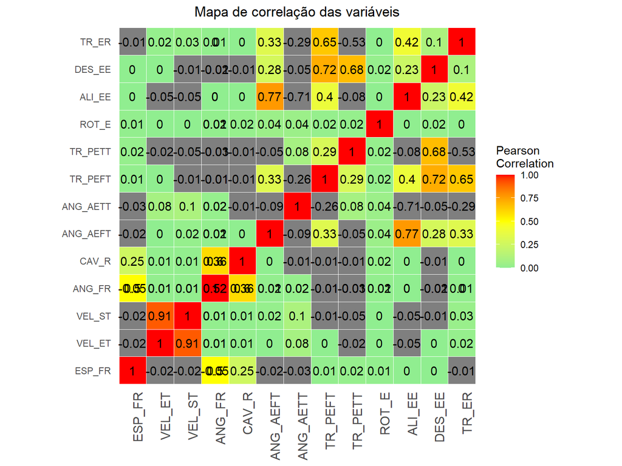

```r
# Medindo a correlação entre ESPESSURA FRISO RODA E EIXO VAGAO
#dim(df_clean)

df_numeric <- select(df_sample_clean,
                     "ESPESSURA_FRISO_RODA",
                      "VELOCIDADE_ENTRADA_TREM",
                     "VELOCIDADE_SAIDA_TREM",
                     "ANGULO_FRISO_RODA",
                     "ALTURA_FRISO_RODA",
                     "CAVA_RODA",
                     "ANGULO_ATAQUE_EIXO_FRONTAL_TRUQUE",
                     "ANGULO_ATAQUE_EIXO_TRASEIRO_TRUQUE",
                     "TRACKING_POSITION_EIXO_FRONTAL_TRUQUE",
                     "TRACKING_POSITION_EIXO_TRASEIRO_TRUQUE",
                     "ROTACAO_EIXO",
                     "ALINHAMENTO_ENTRE_EIXOS_IAM",
                     "DESLOCAMENTO_ENTRE_EIXOS_SHIFT",
                     "TRACKING_ERROR_TE") %>%
                       collect(.)


colnames(df_numeric) <- c("ESP_FR",
                          "VEL_ET",
                           "VEL_ST",
                           "ANG_FR",
                           "ANG_FR",
                           "CAV_R",
                           "ANG_AEFT",
                           "ANG_AETT",
                           "TR_PEFT",
                           "TR_PETT",
                           "ROT_E",
                           "ALI_EE",
                           "DES_EE",
                           "TR_ER")

#cor(sdf_numeric)

cormat <- round(cor(df_numeric),2)
#cormat

# Melt the correlation matrix
melted_cormat <- melt(cormat)
#melted_cormat

# Create a ggheatmap
ggheatmap <- ggplot(melted_cormat, aes(Var2, Var1, fill = value))+
  geom_tile(color = "white")+
  scale_fill_gradient2(low = "light green", high = "red", mid = "yellow",
                       midpoint = 0.5, limit = c(0,1), space = "Lab",
                       name="Pearson\nCorrelation") +
  theme_minimal()+ # minimal theme
  theme(axis.text.x = element_text(angle = 90, vjust = 1,
                                   size = 12, hjust = 1))+
  coord_fixed()

# Outra visão da correlação.
ggheatmap +
  labs(title = "Mapa de correlação das variáveis")+
  geom_text(aes(Var2, Var1, label = value), color = "black", size = 4) +
  theme(
    axis.title.x = element_blank(),
    axis.title.y = element_blank(),
    panel.grid.major = element_blank(),
    panel.border = element_blank(),
    panel.background = element_blank(),
    axis.ticks = element_blank(),
    plot.title = element_text(hjust = 0.5))
```

#### Chart-Correlation

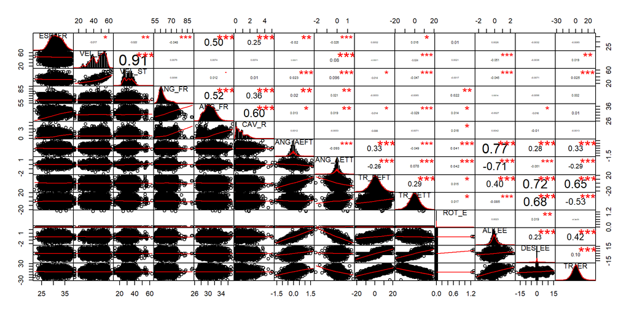

```r
chart.Correlation(df_numeric, histogram=TRUE, pch=19)
```

### BoxPlot

- É possível notar um grande aumento no volume de dados medidos após o mês de Maio de 2018.
- O tamanho das composições aumenta na mesma data.
  - Cada lote são 110 vagões, sendo em média 3 lotes.

#### Friso Mensal

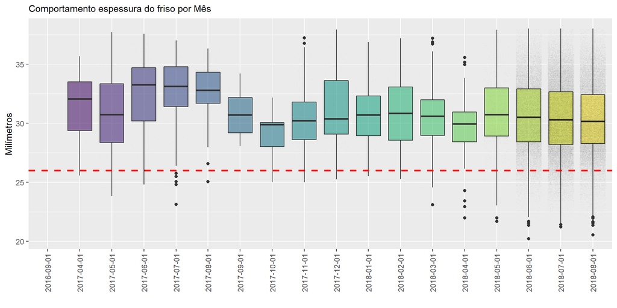

```r
createOrReplaceTempView(df, "tabela")
sdf_vagao_trocas_roda_all <- sql(
"
  select
    *
  from
  tabela

  where CODIGO_VAGAO in
  (
  select
    CODIGO_VAGAO

      from tabela
    where CODIGO_RODA != CICLO_RODEIRO
          and
          CODIGO_VAGAO in
              (select
                  CODIGO_VAGAO
                      from tabela
                    where FRISO_BAIXO ==1
                    group by CODIGO_VAGAO)

    group by CODIGO_VAGAO
  )
    "
)


sdf_vagao_trocas_roda_all %>%
 withColumn("mes_ano",date_trunc("month",.$DIA)) %>%
 collect(.) %>%
 ggplot( aes(x=as.factor(mes_ano), y=ESPESSURA_FRISO_RODA, fill=as.factor(mes_ano))) +
   geom_boxplot() +
   scale_fill_viridis(discrete = TRUE, alpha=0.6) +
   geom_jitter(color="black", size=0.001, alpha=0.01) +
   theme(
     legend.position="none",
     plot.title = element_text(size=11)
   ) +
   #scale_y_continuous(limits = c(0,100))+
   ggtitle("Comportamento espessura do friso por Mês") +
   xlab("")+
   ylab("Milímetros")+
  theme(axis.text.x = element_text(angle = 90, vjust = 0.5, hjust=1))+
  geom_hline(yintercept=26, linetype="dashed", color = "red", size=1)
```

#### Friso Semanal

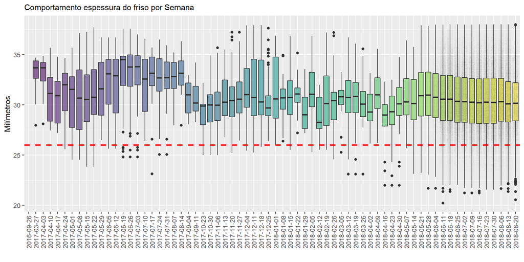

```r
createOrReplaceTempView(df, "tabela")
sdf_vagao_trocas_roda_all <- sql(
"
  select
    *
  from
  tabela

  where CODIGO_VAGAO in
  (
  select
    CODIGO_VAGAO

      from tabela
    where CODIGO_RODA != CICLO_RODEIRO
          and
          CODIGO_VAGAO in
              (select
                  CODIGO_VAGAO
                      from tabela
                    where FRISO_BAIXO ==1
                    group by CODIGO_VAGAO)

    group by CODIGO_VAGAO
  )
    "
)

sdf_vagao_trocas_roda_all %>%
 withColumn("semana_ano",date_trunc("week",.$DIA)) %>%
 collect(.) %>%
 ggplot( aes(x=as.factor(semana_ano), y=ESPESSURA_FRISO_RODA, fill=as.factor(semana_ano))) +
   geom_boxplot() +
   scale_fill_viridis(discrete = TRUE, alpha=0.6) +
   geom_jitter(color="black", size=0.005, alpha=0.01) +
   theme(
     legend.position="none",
     plot.title = element_text(size=11)
   ) +
   #scale_y_continuous(limits = c(0,100))+
   ggtitle("Comportamento espessura do friso por Semana") +
   xlab("")+
   ylab("Milímetros")+
  theme(axis.text.x = element_text(angle = 90, vjust = 0.5, hjust=1))+
  geom_hline(yintercept=26, linetype="dashed", color = "red", size=1)
```

#### Núm Vagões Mensal

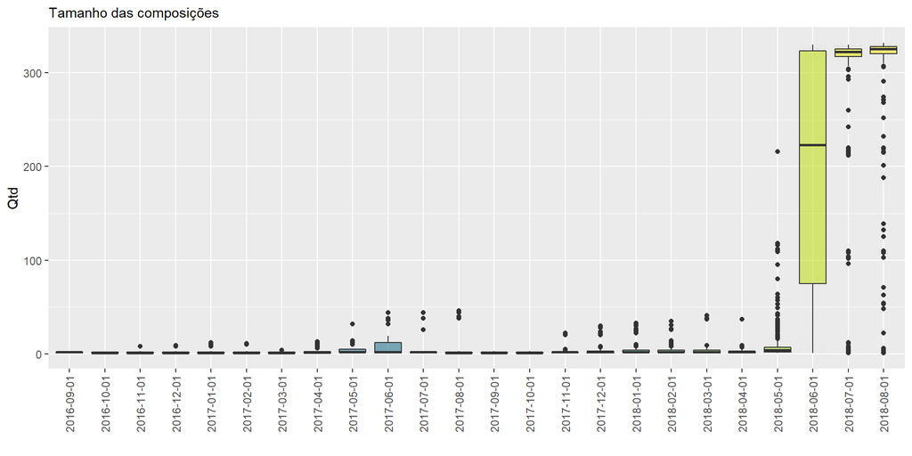

```r
createOrReplaceTempView(df, "tabela")

sql(
  "
select TRAIN_ID, dia, count(*) qtd from
      (
        select TRAIN_ID, CODIGO_VAGAO, dia
        from tabela
        group by TRAIN_ID, CODIGO_VAGAO, dia
      )
group by TRAIN_ID, dia
  "
  ) %>%
 withColumn("mes_ano",date_trunc("month",.$DIA)) %>%
 collect(.) %>%
 ggplot( aes(x=as.factor(mes_ano), y=qtd, fill=as.factor(mes_ano))) +
   geom_boxplot() +
   scale_fill_viridis(discrete = TRUE, alpha=0.6) +
   geom_jitter(color="black", size=0.001, alpha=0.01) +
   theme(
     legend.position="none",
     plot.title = element_text(size=11)
   ) +
   #scale_y_continuous(limits = c(0,100))+
   ggtitle("Tamanho das composições") +
   xlab("")+
   ylab("Qtd")+
  theme(axis.text.x = element_text(angle = 90, vjust = 0.5, hjust=1))
```

```r
  #geom_hline(yintercept=26, linetype="dashed", color = "red", size=1)
```

#### Núm Vagões Semanal

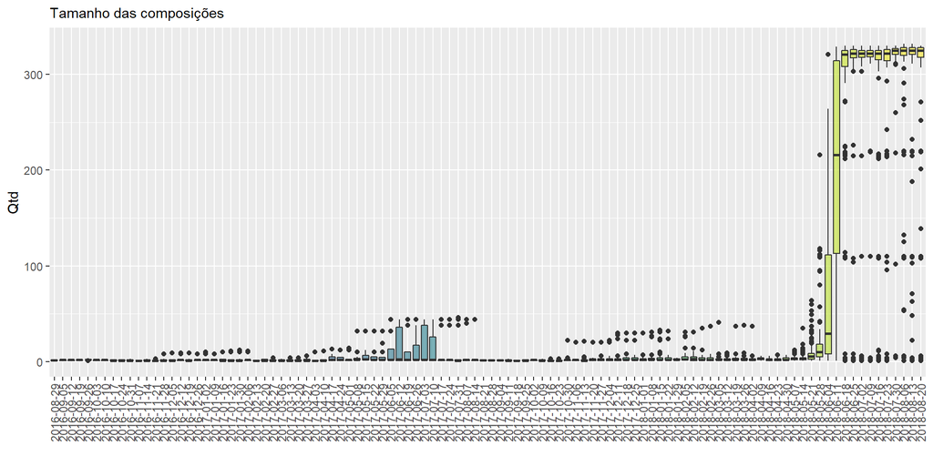

```r
createOrReplaceTempView(df, "tabela")

sql(
  "
select TRAIN_ID, dia, count(*) qtd from
      (
        select TRAIN_ID, CODIGO_VAGAO, dia
        from tabela
        group by TRAIN_ID, CODIGO_VAGAO, dia
      )
group by TRAIN_ID, dia
  "
  ) %>%
 withColumn("semana_ano",date_trunc("week",.$DIA)) %>%
 collect(.) %>%
 ggplot( aes(x=as.factor(semana_ano), y=qtd, fill=as.factor(semana_ano))) +
   geom_boxplot() +
   scale_fill_viridis(discrete = TRUE, alpha=0.6) +
   geom_jitter(color="black", size=0.001, alpha=0.01) +
   theme(
     legend.position="none",
     plot.title = element_text(size=11)
   ) +
   #scale_y_continuous(limits = c(0,100))+
   ggtitle("Tamanho das composições") +
   xlab("")+
   ylab("Qtd")+
  theme(axis.text.x = element_text(angle = 90, vjust = 0.5, hjust=1))
```

```r
  #geom_hline(yintercept=26, linetype="dashed", color = "red", size=1)
```

### Limpando apenas os trens por tamanho lote

```r
createOrReplaceTempView(df, "tabela")

trens_mais_100_vagoes <- sql(
  "

select

TRAIN_ID

from
(
    select TRAIN_ID, dia, count(*) qtd from
      (
          select TRAIN_ID, CODIGO_VAGAO, dia
            from tabela
          group by TRAIN_ID, CODIGO_VAGAO, dia
      )
    group by TRAIN_ID, dia
)
where qtd > 100


  "
  )

#Trens que possem mais que 100 vagões.
trens_validos <- trens_mais_100_vagoes %>% collect()

df_clean <- where(df_clean,df_clean$TRAIN_ID %in% trens_validos$TRAIN_ID) %>%
            where(.,.$DIA > '2018-06-01')
```

### Abertura Históricos Cenário 1

Para facilitar o entendimento do problema foram criadas visualizações temporais de cada roda para os casos onde os trens (TRAIN ID) apresentaram o maior volume de rodas com espessura do friso abaixo de 26mm. A disposição dos gráficos representa as posições das rodas nos trucks e a alteração de cores indica o fim de um ciclo com a troca de um rodeiro.

No cenário 1 foram observados casos em que a apesar dos frisos terem ficado abaixo de 26 mm não ocorreram as trocas do rodeiro. Situação de risco indesejado.

#### Vagão_1

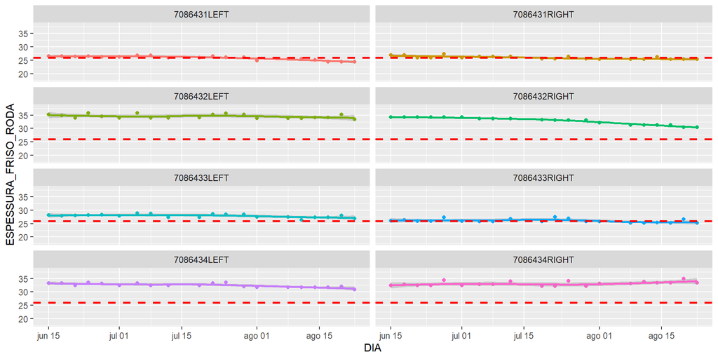

#### Vagão_2

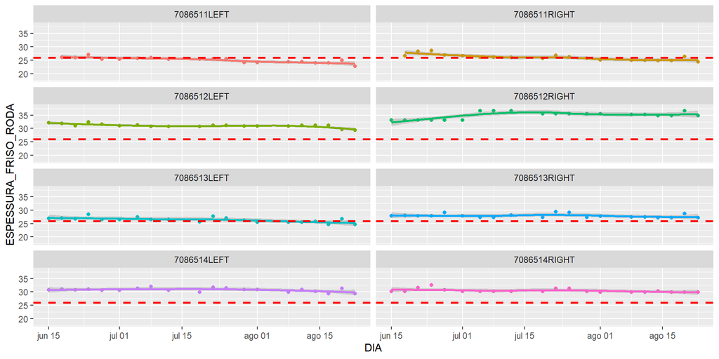

#### Vagão_3

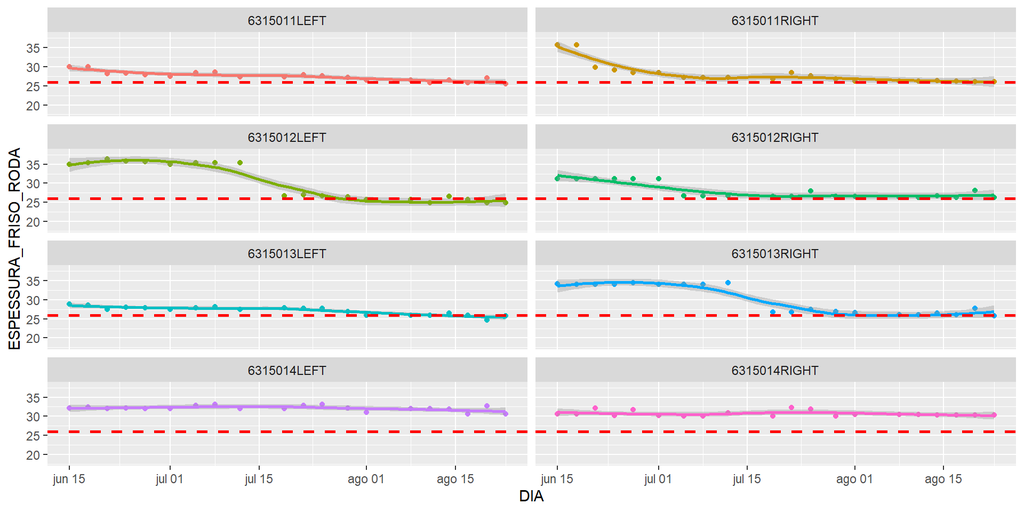

#### Vagão_4

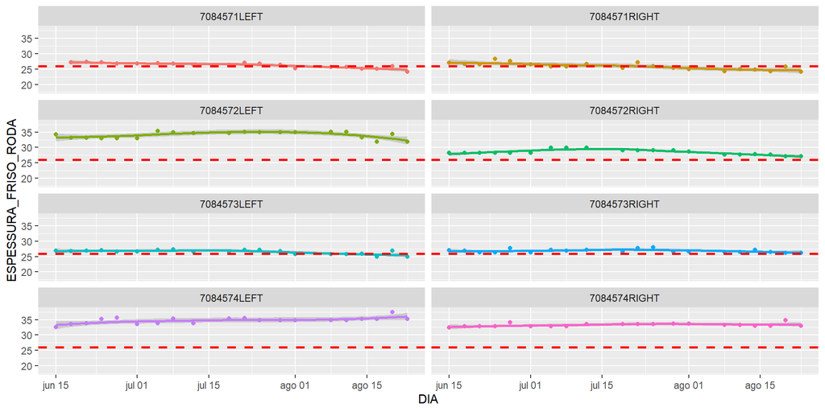

#### Vagão_5

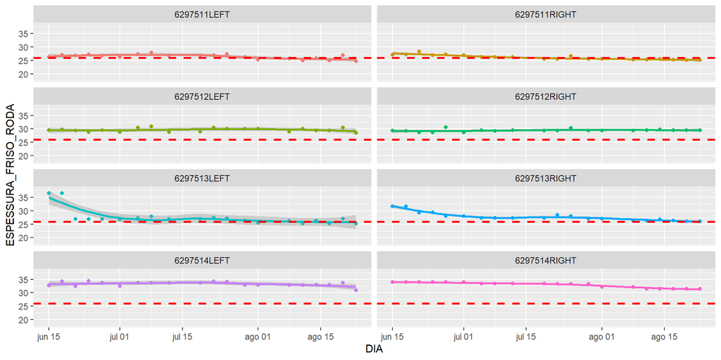

### Abertura Históricos Cenário 2

No cenário 2 foram observados casos em que houveram trocas de rodeiros quando o friso ficou abaixo de 26 mm.

#### Vagão_1

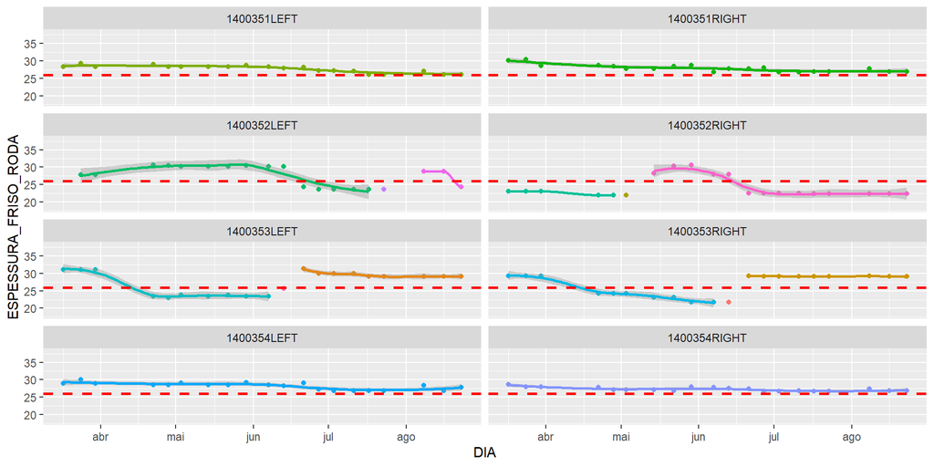

#### Vagão_2

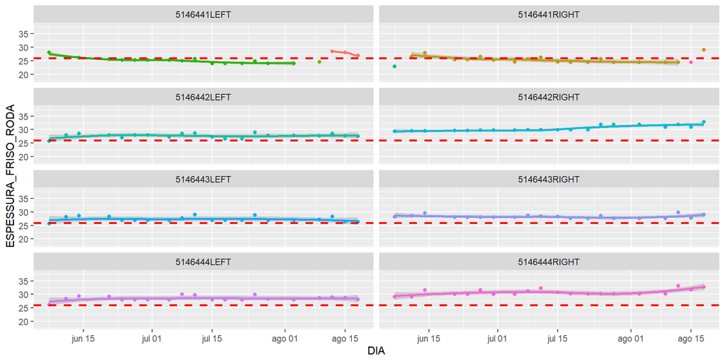

#### Vagão_3

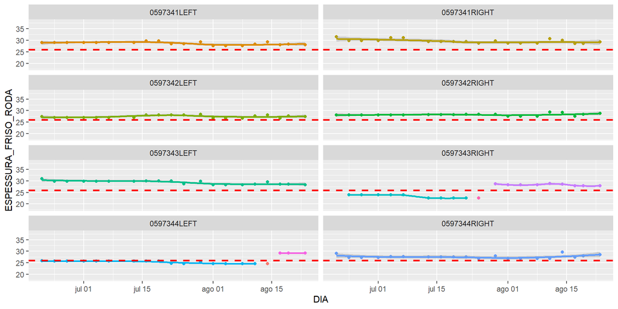

#### Vagão_4

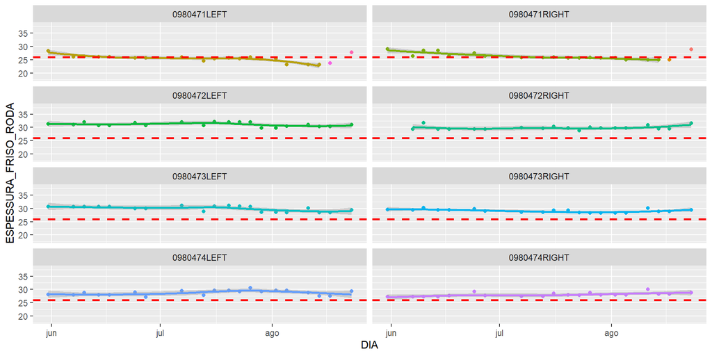

#### Vagão_5

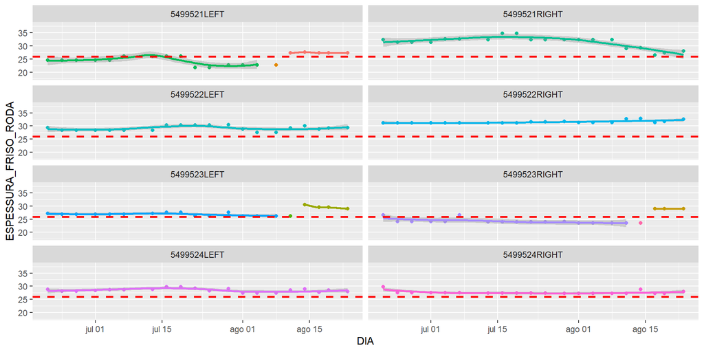

## Preparação dos Dados

### Criação de bases de trabalho

Utilizamos 2 abordagens para realizar a preparação dos dados.

- Utilizar a base limpa (df_clean) sem alteração nos registros (df_clean) com balanceamento entre 0 e 1
- Utilizar a base limpa (df_clean) com shift de resultados agrupado por roda/dia (df_pivot_spark)

#### Base Clean

A base df_clean é a base limpa com o balanceamento da base de testes. O balanceamento (undersample) foi realizado da seguinte forma:

```r
# Criar undersampling
createOrReplaceTempView(df_clean, "tabela")

# Criando uma tabela apenas com Sim
sdf_yes <- sql("
SELECT * FROM tabela WHERE FRISO_BAIXO=1 ORDER BY DIA DESC"
    )
#dim(sdf_yes)
#head(sdf_yes,100)

yes_sample <- sdf_yes %>% sample(withReplacement = F,fraction = 0.7)

createOrReplaceTempView(yes_sample, "tabela_yes")

yes <- sql("SELECT COUNT(*) FROM tabela_yes") %>% head()
#yes

# Criando uma tabela apenas com Não
sdf_no <- sql("
SELECT * FROM tabela WHERE FRISO_BAIXO=0 ORDER BY DIA DESC"
    )
#dim(sdf_no)
#head(sdf_no,100)

createOrReplaceTempView(sdf_no, "tabela_no")

no <- sql("SELECT COUNT(*) FROM tabela_no") %>% head()

sample_value <- yes[1]/no[1]
sample_value <- sample_value[[1]]
#class(sample_value)
#sample_value

fbal <-  3 # Fator de balanceamento, quantas vezes a base negativa será em relação a positiva

no_sample <- sdf_no %>% sample(withReplacement = F,fraction = fbal*sample_value)

#dim(no_sample)
#dim(yes_sample)

df_undersampling <- rbind(yes_sample,no_sample)
#dim(df_undersampling)

SparkR::head(summarize(groupBy(df_undersampling,df_undersampling$FRISO_BAIXO), count=n(df$ROW_ID)))
```

```
##   FRISO_BAIXO count
## 1           0 49480
## 2           1 16509
```

```r
# Dividindo entre treino e teste

df_clean_train <- df_undersampling
df_clean_test <- except(df_clean, df_undersampling)

#dim(df_clean_train)
#dim(df_clean_test)
```

#### Base Pivot

Passos realizados para criar a base de treino:

1. Under sampling: Para treino foram utilizadas as medições das rodas que estiveram no trem com o maior número de rodas com friso baixo na última medição. Por exemplo: TRAIN_ID = 25B7F2F33 com 157 rodas com FRISO_BAIXO=1.

|  | TRAIN_ID | DIA | Quantidade_Rodas_Friso_Baixo |
| --- | --- | --- | --- |
| 1 | 25B7F2F33 | 2018-08-23 | 157 |
| 2 | 25B78C28A | 2018-08-19 | 110 |
| 3 | 25B79C047 | 2018-08-19 | 101 |
| 4 | 25B7B75CD | 2018-08-21 | 89 |
| 5 | 25B79A01E | 2018-08-19 | 84 |

```r
#Trem com o maior número de rodas com o friso baixo.
createOrReplaceTempView(where(df,df$TRAIN_ID=='25B7F2F33'), "tabela_pior_trem")

#createOrReplaceTempView(where(df,df$TRAIN_ID %in% piores_trens$TRAIN_ID), "tabela_pior_trem")

vagoes <- sql("
              select CODIGO_VAGAO,DIA
              from tabela_pior_trem
              group by CODIGO_VAGAO,DIA
              order by CODIGO_VAGAO,DIA desc") %>% collect()

#Criando uma tabela com os dados dos vagões que estavam no trem que teve o maior número de rodas com friso baixo (considerando o pior trêm).

createOrReplaceTempView(where(df_clean,df_clean$CODIGO_VAGAO %in% vagoes$CODIGO_VAGAO), "tabela_vagoes_do_pior_trem")

tabela_all <- sql("select * from tabela_vagoes_do_pior_trem")

#Foi necessário criar um rank pois as rodas tem medidas em dias diferentes.
#Criando uma tabela com o rank para classificar a "idade" da medição.
tabela_rank <- sql("select CODIGO_VAGAO,DIA,  RANK() OVER (PARTITION BY CODIGO_VAGAO ORDER BY DIA desc)  Rank

              from tabela_vagoes_do_pior_trem
              group by CODIGO_VAGAO,DIA
              order by CODIGO_VAGAO,DIA desc
")

tabela_join <- join(tabela_all, tabela_rank,
     tabela_all$DIA==tabela_rank$DIA
     &
    tabela_all$CODIGO_VAGAO==tabela_rank$CODIGO_VAGAO)



df_pivot <- tabela_join %>%
  #withColumn("roda_trocada",when(.$CICLO_RODEIRO = .$ ROW_ID, 1).otherwise(0)) %>%
  drop(c("DATA_HORA_LEITURA","CODIGO_RODEIRO","CODIGO_VAGAO","SENTIDO_TREM","TRAIN_ID","POSICAO_VAGAO_COMPOSICAO","DIA","FRISO_MENOR_QUE_26")) %>%
#"EIXO_VAGAO" e "LADO_RODA" devem ser mantiodos
#definindo o perído avaliação.
  where(.,.$Rank<=3) %>%
  collect() %>%
#Usando "ROW_ID","CICLO_RODEIRO" para identificar mudanças de rodeiros.
  dplyr::mutate(roda_trocada=if_else(.$ROW_ID==.$CICLO_RODEIRO,1,0)) %>%
  dplyr::select(-ROW_ID,-CICLO_RODEIRO) %>%
  dplyr::distinct() %>%
#usando o str_pad para conseguir organizar melhor as colunas.
  dplyr::mutate(Rank_2=str_pad(.$Rank, 2, pad = "0"),LADO_RODA=if_else(LADO_RODA=="RIGHT",1,0)) %>%
  dplyr::select(-Rank) %>%
  pivot_wider(names_from = c(Rank_2),values_from = c(colunas_numeric$medidas,roda_trocada),values_fn = max) %>%
#A coluna row foi usada como um artifício para evitar criar uma pivot com valores
  dplyr::select(sort(names(.))) %>%
  dplyr::select(CODIGO_RODA,FRISO_BAIXO_01,EIXO_VAGAO,LADO_RODA,roda_trocada_01,everything()) %>%
#Removendo as colunas das medições atuais (mais recente) e mantendo a variável dependente.
  dplyr::rename(FRISO_BAIXO=FRISO_BAIXO_01,roda_trocada=roda_trocada_01) %>%
  dplyr::select(-colnames(.[which(substr(colnames(.),nchar(colnames(.))-1,nchar(colnames(.)))=="01")]))


df_pivot <- na.omit(df_pivot)

#Voltando para spark
df_pivot_spark <- createDataFrame(df_pivot, schema = NULL)

#head(df_pivot_spark,100) %>% View()

ncol_pivot_spark <- ncol(df_pivot_spark)
#ncol_pivot_spark

#Limpeza adicional
#Completando os valores nulos com as médias.
#resumo_medidas$media

for (i in 1:ncol_pivot_spark){
  df_pivot_spark <- df_pivot_spark %>% where(.,!isNull(.[[i]]))
}

head(df_pivot_spark) %>% rmarkdown::paged_table()
```

|  | CODIGO_RODA | FRISO_BAIXO | EIXO_VAGAO | LADO_RODA | roda_trocada | ALINHAMENTO_ENTRE_EIXOS_IAM_02 | ALINHAMENTO_ENTRE_EIXOS_IAM_03 | ALTURA_FRISO_RODA_02 | ALTURA_FRISO_RODA_03 | ANGULO_ATAQUE_EIXO_FRONTAL_TRUQUE_02 | ANGULO_ATAQUE_EIXO_FRONTAL_TRUQUE_03 | ANGULO_ATAQUE_EIXO_TRASEIRO_TRUQUE_02 | ANGULO_ATAQUE_EIXO_TRASEIRO_TRUQUE_03 | ANGULO_FRISO_RODA_02 | ANGULO_FRISO_RODA_03 | CAVA_RODA_02 | CAVA_RODA_03 | DESLOCAMENTO_ENTRE_EIXOS_SHIFT_02 | DESLOCAMENTO_ENTRE_EIXOS_SHIFT_03 | ESPESSURA_FRISO_RODA_02 | ESPESSURA_FRISO_RODA_03 | FRISO_BAIXO_02 | FRISO_BAIXO_03 | roda_trocada_02 | roda_trocada_03 | ROTACAO_EIXO_02 | ROTACAO_EIXO_03 | SERPENTEAMENTO_HUNTING_02 | SERPENTEAMENTO_HUNTING_03 | … |
| --- | --- | --- | --- | --- | --- | --- | --- | --- | --- | --- | --- | --- | --- | --- | --- | --- | --- | --- | --- | --- | --- | --- | --- | --- | --- | --- | --- | --- | --- | --- |
| 1 | 0525272RIGHT | 0 | 2 | 1 | 0 | -0.1 | -0.1 | 30.03 | 30.03 | -0.1 | -0.1 | 0.0 | 0.0 | 59.124 | 59.124 | 0.09 | 0.10 | 0 | 0 | 30.12 | 30.19 | 0 | 0 | 0 | 0 | 0 | 0 | 0 | 0 | … |
| 2 | 0525271RIGHT | 0 | 1 | 1 | 0 | -0.1 | -0.1 | 30.72 | 30.72 | -0.1 | -0.1 | 0.0 | 0.0 | 57.813 | 57.813 | 0.21 | 0.49 | 0 | 0 | 31.89 | 32.28 | 0 | 0 | 0 | 0 | 0 | 0 | 0 | 0 | … |
| 3 | 0525274LEFT | 0 | 4 | 0 | 0 | 0.4 | 0.4 | 29.88 | 29.88 | 0.3 | 0.3 | -0.1 | -0.1 | 58.965 | 58.965 | 0.49 | 0.49 | 0 | 0 | 32.63 | 32.63 | 0 | 0 | 0 | 0 | 0 | 0 | 0 | 0 | … |
| 4 | 0525273LEFT | 0 | 3 | 0 | 0 | 0.4 | 0.4 | 29.97 | 29.97 | 0.3 | 0.3 | -0.1 | -0.1 | 59.038 | 59.038 | 0.37 | 0.37 | 0 | 0 | 28.55 | 29.95 | 0 | 0 | 0 | 0 | 0 | 0 | 0 | 0 | … |
| 5 | 0525271LEFT | 0 | 1 | 0 | 0 | -0.1 | -0.1 | 30.46 | 30.26 | -0.1 | -0.1 | 0.0 | 0.0 | 57.832 | 57.832 | 0.38 | 0.14 | 0 | 0 | 30.15 | 31.47 | 0 | 0 | 0 | 0 | 0 | 0 | 0 | 0 | … |
| 6 | 0525272LEFT | 0 | 2 | 0 | 0 | -0.1 | -0.1 | 29.76 | 29.76 | -0.1 | -0.1 | 0.0 | 0.0 | 57.578 | 57.578 | 0.31 | 0.31 | 0 | 0 | 28.85 | 31.04 | 0 | 0 | 0 | 0 | 0 | 0 | 0 | 0 | … |

```r
#printSchema(df_pivot_spark)
#class(df_pivot_spark)

#head(df_pivot_spark)
```

Criando a base de teste df_pivot_spark (outro trem)

```r
#createOrReplaceTempView(where(df,df$TRAIN_ID=='25B7F2F33'), "tabela_pior_trem")
#createOrReplaceTempView(where(df,df$TRAIN_ID %in% piores_trens$TRAIN_ID), "tabela_pior_trem")

#vagoes <- sql("
#              select CODIGO_VAGAO,DIA
#              from tabela_pior_trem
#              group by CODIGO_VAGAO,DIA
#              order by CODIGO_VAGAO,DIA desc") %>% collect()

createOrReplaceTempView(where(df_clean,df_clean$TRAIN_ID != '25B7F2F33'), "tabela_vagoes_menos_pior_trem")

tabela_all <- sql("select * from tabela_vagoes_menos_pior_trem")

tabela_rank <- sql("select CODIGO_VAGAO,DIA,  RANK() OVER (PARTITION BY CODIGO_VAGAO ORDER BY DIA desc)  Rank

              from tabela_vagoes_menos_pior_trem
              group by CODIGO_VAGAO,DIA
              order by CODIGO_VAGAO,DIA desc
")

tabela_join <- join(tabela_all, tabela_rank,
     tabela_all$DIA==tabela_rank$DIA
     &
      tabela_all$CODIGO_VAGAO==tabela_rank$CODIGO_VAGAO)

df_pivot_teste <- tabela_join %>%
  #withColumn("roda_trocada",when(.$CICLO_RODEIRO = .$ ROW_ID, 1).otherwise(0)) %>%
  drop(c("DATA_HORA_LEITURA","CODIGO_RODEIRO","CODIGO_VAGAO","SENTIDO_TREM","TRAIN_ID","POSICAO_VAGAO_COMPOSICAO","DIA","FRISO_MENOR_QUE_26")) %>%
#"EIXO_VAGAO" e "LADO_RODA" devem ser mantiodos
#definindo o perído avaliação.
  where(.,.$Rank<=3) %>%
  collect() %>%
#Usando "ROW_ID","CICLO_RODEIRO" para identificar mudanças de rodeiros.
  dplyr::mutate(roda_trocada=if_else(.$ROW_ID==.$CICLO_RODEIRO,1,0)) %>%
  dplyr::select(-ROW_ID,-CICLO_RODEIRO) %>%
  dplyr::distinct() %>%
#usando o str_pad para conseguir organizar melhor as colunas.
  dplyr::mutate(Rank_2=str_pad(.$Rank, 2, pad = "0"),LADO_RODA=if_else(LADO_RODA=="RIGHT",1,0)) %>%
  dplyr::select(-Rank) %>%
  pivot_wider(names_from = c(Rank_2),values_from = c(colunas_numeric$medidas,roda_trocada),values_fn = max) %>%
#A coluna row foi usada como um artifício para evitar criar uma pivot com valores
  dplyr::select(sort(names(.))) %>%
  dplyr::select(CODIGO_RODA,FRISO_BAIXO_01,EIXO_VAGAO,LADO_RODA,roda_trocada_01,everything()) %>%
#Removendo as colunas das medições atuais (mais recente) e mantendo a variável dependente.
  dplyr::rename(FRISO_BAIXO=FRISO_BAIXO_01,roda_trocada=roda_trocada_01) %>%
  dplyr::select(-colnames(.[which(substr(colnames(.),nchar(colnames(.))-1,nchar(colnames(.)))=="01")]))


df_pivot_teste <- na.omit(df_pivot_teste)

#Voltando para spark

df_pivot_spark_teste <- createDataFrame(df_pivot_teste, schema = NULL)
```

## Modelagem

### Modelo 1

O primeiro modelo criado foi utilizando a base clean e não foram encontrados bons resultados.

#### Regressão Logística

```r
model_clean_rl <- spark.logit(df_clean_train, FRISO_BAIXO ~
                       VELOCIDADE_ENTRADA_TREM+
                       VELOCIDADE_SAIDA_TREM+
                       ANGULO_FRISO_RODA+
                       ALTURA_FRISO_RODA+
                       CAVA_RODA+
                       ANGULO_ATAQUE_EIXO_FRONTAL_TRUQUE+
                       ANGULO_ATAQUE_EIXO_TRASEIRO_TRUQUE+
                       TRACKING_POSITION_EIXO_FRONTAL_TRUQUE+
                       TRACKING_POSITION_EIXO_TRASEIRO_TRUQUE+
                       ROTACAO_EIXO+
                       ALINHAMENTO_ENTRE_EIXOS_IAM+
                       DESLOCAMENTO_ENTRE_EIXOS_SHIFT+
                       TRACKING_ERROR_TE,
                       thresholds = 0.5,
                     regParam = 0.5)
# Modelo básico de regressão logística
fitted_rl <- predict(model_clean_rl, df_clean_test)

createOrReplaceTempView(fitted_rl, "predictions_rl")

#dim(df_test)

#correct_rl <- sql("SELECT prediction, FRISO_BAIXO FROM predictions_rl WHERE prediction=FRISO_BAIXO")
#head(correct)

#acc_rl = count(correct_rl)/count(fitted_rl)
#acc_rl

# Matriz de confusao
conf_matrix <- data.frame()

model_rl_TP <- sql("SELECT COUNT(1) as TRUE_POSITIVE FROM predictions_rl
                    WHERE FRISO_BAIXO=1 AND prediction=1
                    ") %>% head(1)

#model_rl_TP[1,1]
conf_matrix[1,1] <- model_rl_TP[1,1]

model_rl_FP <- sql("SELECT COUNT(1) as FALSE_POSITIVE FROM predictions_rl
                    WHERE FRISO_BAIXO=0 AND prediction=1
                    ") %>% head(1)
#model_rl_FP[1,1]
conf_matrix[2,1] <- model_rl_FP[1,1]

model_rl_TN <- sql("SELECT COUNT(1) as TRUE_NEGATIVE FROM predictions_rl
                    WHERE FRISO_BAIXO=0 AND prediction=0
                    ") %>% head(1)
#model_rl_TN[1,1]
conf_matrix[2,2] <- model_rl_TN[1,1]

model_rl_FN <- sql("SELECT COUNT(1) as FALSE_NEGATIVE FROM predictions_rl
                    WHERE FRISO_BAIXO=1 AND prediction=0
                    ") %>% head(1)
#model_rl_FN[1,1]
conf_matrix[1,2] <- model_rl_FN[1,1]

colnames(conf_matrix) <- c("PRED_TRUE","PRED_FALSE")
rownames(conf_matrix) <- c("REAL_TRUE","REAL_FALSE")

conf_matrix %>% kable(., format = "html",row.names = T, digits = 2) %>%
kable_styling(bootstrap_options = c("striped","hover","condensed","responsive"))
```

|  | PRED_TRUE | PRED_FALSE |
| --- | --- | --- |
| REAL_TRUE | 1 | 7041 |
| REAL_FALSE | 201 | 2006669 |

```r
acuracia <- (conf_matrix[1,1]+conf_matrix[2,2])/(conf_matrix[1,1]+conf_matrix[2,2]+conf_matrix[1,2]+conf_matrix[2,1])
precisao <- conf_matrix[1,1]/(conf_matrix[1,1]+conf_matrix[2,1])
sensibilidade <- conf_matrix[1,1]/(conf_matrix[1,1]+conf_matrix[2,1])
especificidade <- conf_matrix[2,2]/(conf_matrix[2,2]+conf_matrix[2,1])
```

| Indicador | Coluna |
| --- | --- |
| Acurácia | 1 |
| Precisao | 0 |
| Sensibilidade | 0 |
| Especificidade | 1 |

#### Summary Regressão Logística

```r
model_clean_rl <- spark.logit(df_clean_train, FRISO_BAIXO ~
                       VELOCIDADE_ENTRADA_TREM+
                       VELOCIDADE_SAIDA_TREM+
                       ANGULO_FRISO_RODA+
                       ALTURA_FRISO_RODA+
                       CAVA_RODA+
                       ANGULO_ATAQUE_EIXO_FRONTAL_TRUQUE+
                       ANGULO_ATAQUE_EIXO_TRASEIRO_TRUQUE+
                       TRACKING_POSITION_EIXO_FRONTAL_TRUQUE+
                       TRACKING_POSITION_EIXO_TRASEIRO_TRUQUE+
                       ROTACAO_EIXO+
                       ALINHAMENTO_ENTRE_EIXOS_IAM+
                       DESLOCAMENTO_ENTRE_EIXOS_SHIFT+
                       TRACKING_ERROR_TE,
                       thresholds = 0.5,
                     regParam = 0.5)
summary(model_clean_rl)
```

```
## $coefficients
##                                             Estimate
## (Intercept)                            -3.4383422192
## VELOCIDADE_ENTRADA_TREM                 0.0031085646
## VELOCIDADE_SAIDA_TREM                   0.0052491019
## ANGULO_FRISO_RODA                       0.0465301838
## ALTURA_FRISO_RODA                      -0.0340144825
## CAVA_RODA                               0.1250130764
## ANGULO_ATAQUE_EIXO_FRONTAL_TRUQUE       0.0843731803
## ANGULO_ATAQUE_EIXO_TRASEIRO_TRUQUE      0.0860467306
## TRACKING_POSITION_EIXO_FRONTAL_TRUQUE   0.0035753246
## TRACKING_POSITION_EIXO_TRASEIRO_TRUQUE -0.0007947008
## ROTACAO_EIXO                           -0.0945888318
## ALINHAMENTO_ENTRE_EIXOS_IAM             0.0072200985
## DESLOCAMENTO_ENTRE_EIXOS_SHIFT          0.0047646750
## TRACKING_ERROR_TE                       0.0031777248
```

#### Random Forest

```r
model_clean_rf <- spark.randomForest(df_clean_train, FRISO_BAIXO ~
                       VELOCIDADE_ENTRADA_TREM+
                       VELOCIDADE_SAIDA_TREM+
                       ANGULO_FRISO_RODA+
                       ALTURA_FRISO_RODA+
                       CAVA_RODA+
                       ANGULO_ATAQUE_EIXO_FRONTAL_TRUQUE+
                       ANGULO_ATAQUE_EIXO_TRASEIRO_TRUQUE+
                       TRACKING_POSITION_EIXO_FRONTAL_TRUQUE+
                       TRACKING_POSITION_EIXO_TRASEIRO_TRUQUE+
                       ROTACAO_EIXO+
                       ALINHAMENTO_ENTRE_EIXOS_IAM+
                       DESLOCAMENTO_ENTRE_EIXOS_SHIFT+
                       TRACKING_ERROR_TE+
                       SERPENTEAMENTO_HUNTING,
                       "classification",
                     numTrees = 10)

# Modelo básico de random forest
fitted_rf <- predict(model_clean_rf, df_clean_test)

createOrReplaceTempView(fitted_rf, "predictions_rf")

# Matriz de confusao
conf_matrix <- data.frame()

model_rf_TP <- sql("SELECT COUNT(1) as TRUE_POSITIVE FROM predictions_rf
                    WHERE FRISO_BAIXO=1 AND prediction=1
                    ") %>% head(1)

#model_rf_TP[1,1]
conf_matrix[1,1] <- model_rf_TP[1,1]

model_rf_FP <- sql("SELECT COUNT(1) as FALSE_POSITIVE FROM predictions_rf
                    WHERE FRISO_BAIXO=0 AND prediction=1
                    ") %>% head(1)
#model_rf_FP[1,1]
conf_matrix[2,1] <- model_rf_FP[1,1]

model_rf_TN <- sql("SELECT COUNT(1) as TRUE_NEGATIVE FROM predictions_rf
                    WHERE FRISO_BAIXO=0 AND prediction=0
                    ") %>% head(1)
#model_rf_TN[1,1]
conf_matrix[2,2] <- model_rf_TN[1,1]

model_rf_FN <- sql("SELECT COUNT(1) as FALSE_NEGATIVE FROM predictions_rf
                    WHERE FRISO_BAIXO=1 AND prediction=0
                    ") %>% head(1)
#model_rf_FN[1,1]
conf_matrix[1,2] <- model_rf_FN[1,1]

colnames(conf_matrix) <- c("PRED_TRUE","PRED_FALSE")
rownames(conf_matrix) <- c("REAL_TRUE","REAL_FALSE")

conf_matrix %>% kable(., format = "html",row.names = T, digits = 2) %>%
kable_styling(bootstrap_options = c("striped","hover","condensed","responsive"))
```

|  | PRED_TRUE | PRED_FALSE |
| --- | --- | --- |
| REAL_TRUE | 4425 | 2617 |
| REAL_FALSE | 180385 | 1826485 |

```r
acuracia <- (conf_matrix[1,1]+conf_matrix[2,2])/(conf_matrix[1,1]+conf_matrix[2,2]+conf_matrix[1,2]+conf_matrix[2,1])
precisao <- conf_matrix[1,1]/(conf_matrix[1,1]+conf_matrix[2,1])
sensibilidade <- conf_matrix[1,1]/(conf_matrix[1,1]+conf_matrix[2,1])
especificidade <- conf_matrix[2,2]/(conf_matrix[2,2]+conf_matrix[2,1])
```

| Indicador | Coluna |
| --- | --- |
| Acurácia | 0.91 |
| Precisao | 0.02 |
| Sensibilidade | 0.02 |
| Especificidade | 0.91 |

#### Summary Random Forest

```r
model_clean_rf <- spark.randomForest(df_clean_train, FRISO_BAIXO ~
                       VELOCIDADE_ENTRADA_TREM+
                       VELOCIDADE_SAIDA_TREM+
                       ANGULO_FRISO_RODA+
                       ALTURA_FRISO_RODA+
                       CAVA_RODA+
                       ANGULO_ATAQUE_EIXO_FRONTAL_TRUQUE+
                       ANGULO_ATAQUE_EIXO_TRASEIRO_TRUQUE+
                       TRACKING_POSITION_EIXO_FRONTAL_TRUQUE+
                       TRACKING_POSITION_EIXO_TRASEIRO_TRUQUE+
                       ROTACAO_EIXO+
                       ALINHAMENTO_ENTRE_EIXOS_IAM+
                       DESLOCAMENTO_ENTRE_EIXOS_SHIFT+
                       TRACKING_ERROR_TE+
                       SERPENTEAMENTO_HUNTING,
                       "classification",
                     numTrees = 10)
summary(model_clean_rf)
```

```
## Formula:  FRISO_BAIXO ~ VELOCIDADE_ENTRADA_TREM + VELOCIDADE_SAIDA_TREM +     ANGULO_FRISO_RODA + ALTURA_FRISO_RODA + CAVA_RODA + ANGULO_ATAQUE_EIXO_FRONTAL_TRUQUE +     ANGULO_ATAQUE_EIXO_TRASEIRO_TRUQUE + TRACKING_POSITION_EIXO_FRONTAL_TRUQUE +     TRACKING_POSITION_EIXO_TRASEIRO_TRUQUE + ROTAC…
## Number of features:  14
## Features:  VELOCIDADE_ENTRADA_TREM VELOCIDADE_SAIDA_TREM ANGULO_FRISO_RODA ALTURA_FRISO_RODA CAVA_RODA ANGULO_ATAQUE_EIXO_FRONTAL_TRUQUE ANGULO_ATAQUE_EIXO_TRASEIRO_TRUQUE TRACKING_POSITION_EIXO_FRONTAL_TRUQUE TRACKING_POSITION_EIXO_TRASEIRO_TRUQUE ROTACAO_EIXO ALINHAMENTO_ENTRE_EIXOS_IAM DESLOCA…
## Feature importances:  (14,[0,1,2,3,4,5,6,7,8,9,10,11,12],[6.713374678092144E-4,6.726330242143885E-4,0.34466814859562034,0.41612166409436285,0.14569495293937018,0.0016551066644642652,0.004660842224711723,0.06137112564262502,9.744866870819279E-4,1.5526744454977829E-4,8.59896554947705E-4,0.012587480…
## Max Depth:  5
## Number of trees:  10
## Tree weights:  1 1 1 1 1 1 1 1 1 1
##  RandomForestClassificationModel: uid=rfc_7720b9901b33, numTrees=10, numClasses=2, numFeatures=14
##   Tree 0 (weight 1.0):
##     If (feature 2 <= 70.09199905395505)
##      If (feature 7 <= 8.116666793823246)
##       If (feature 5 <= -0.316666677594185)
##        If (feature 3 <= 28.73499965667725)
##         If (feature 2 <= 61.39749908447265)
##          Predict: 0.0
##         Else (feature 2 > 61.39749908447265)
##          Predict: 1.0
##        Else (feature 3 > 28.73499965667725)
##         Predict: 0.0
##       Else (feature 5 > -0.316666677594185)
##        If (feature 6 <= 0.299999997019768)
##         Predict: 0.0
##        Else (feature 6 > 0.299999997019768)
##         If (feature 3 <= 28.73499965667725)
##          Predict: 1.0
##         Else (feature 3 > 28.73499965667725)
##          Predict: 0.0
##      Else (feature 7 > 8.116666793823246)
##       If (feature 1 <= 31.5)
##        If (feature 11 <= 0.0249999761581421)
##         If (feature 3 <= 28.9749994277954)
##          Predict: 1.0
##         Else (feature 3 > 28.9749994277954)
##          Predict: 0.0
##        Else (feature 11 > 0.0249999761581421)
##         Predict: 0.0
##       Else (feature 1 > 31.5)
##        If (feature 3 <= 28.73499965667725)
##         If (feature 0 <= 37.5)
##          Predict: 0.0
```

[output cut: 505 more lines]

```
##        If (feature 2 <= 59.0625)
##         Predict: 1.0
##        Else (feature 2 > 59.0625)
##         Predict: 0.0
##       Else (feature 2 > 71.4309997558594)
##        If (feature 8 <= 8.616666793823246)
##         Predict: 1.0
##        Else (feature 8 > 8.616666793823246)
##         If (feature 11 <= 8.716666221618656)
##          Predict: 0.0
##         Else (feature 11 > 8.716666221618656)
##          Predict: 1.0
##      Else (feature 3 > 33.0249996185303)
##       Predict: 1.0
##
```

### Modelo 2

Como o modelo 1 não teve uma boa performance, decidimos buscar um tratamento da base para incluir os dados históricos de medição (df_pivot). Com isso, a regressão logística não apresentou um bom desempenho porém o modelo random forest apresentou um resultado satisfatório, sendo este o escolhido para a solução do problema.

#### Regressão Logística

```r
model_pivot_rl <- spark.logit(df_pivot_spark %>% drop("CODIGO_RODA"),
                              FRISO_BAIXO ~ ., thresholds = 0.5,
                     regParam = 0.5)
# Modelo básico de regressão logística
fitted_rl <- predict(model_pivot_rl, df_pivot_spark_teste)

createOrReplaceTempView(fitted_rl, "predictions_rl")

#dim(df_test)

#correct_rl <- sql("SELECT prediction, FRISO_BAIXO FROM predictions_rl WHERE prediction=FRISO_BAIXO")
#head(correct)

#acc_rl = count(correct_rl)/count(fitted_rl)
#acc_rl

# Matriz de confusao
conf_matrix <- data.frame()

model_rl_TP <- sql("SELECT COUNT(1) as TRUE_POSITIVE FROM predictions_rl
                    WHERE FRISO_BAIXO=1 AND prediction=1
                    ") %>% head(1)

#model_rl_TP[1,1]
conf_matrix[1,1] <- model_rl_TP[1,1]

model_rl_FP <- sql("SELECT COUNT(1) as FALSE_POSITIVE FROM predictions_rl
                    WHERE FRISO_BAIXO=0 AND prediction=1
                    ") %>% head(1)
#model_rl_FP[1,1]
conf_matrix[2,1] <- model_rl_FP[1,1]

model_rl_TN <- sql("SELECT COUNT(1) as TRUE_NEGATIVE FROM predictions_rl
                    WHERE FRISO_BAIXO=0 AND prediction=0
                    ") %>% head(1)
#model_rl_TN[1,1]
conf_matrix[2,2] <- model_rl_TN[1,1]

model_rl_FN <- sql("SELECT COUNT(1) as FALSE_NEGATIVE FROM predictions_rl
                    WHERE FRISO_BAIXO=1 AND prediction=0
                    ") %>% head(1)
#model_rl_FN[1,1]
conf_matrix[1,2] <- model_rl_FN[1,1]

colnames(conf_matrix) <- c("PRED_TRUE","PRED_FALSE")
rownames(conf_matrix) <- c("REAL_TRUE","REAL_FALSE")

conf_matrix %>% kable(., format = "html",row.names = T, digits = 2) %>%
kable_styling(bootstrap_options = c("striped","hover","condensed","responsive"))
```

|  | PRED_TRUE | PRED_FALSE |
| --- | --- | --- |
| REAL_TRUE | 48 | 2229 |
| REAL_FALSE | 0 | 122350 |

```r
acuracia <- (conf_matrix[1,1]+conf_matrix[2,2])/(conf_matrix[1,1]+conf_matrix[2,2]+conf_matrix[1,2]+conf_matrix[2,1])
precisao <- conf_matrix[1,1]/(conf_matrix[1,1]+conf_matrix[2,1])
sensibilidade <- conf_matrix[1,1]/(conf_matrix[1,1]+conf_matrix[2,1])
especificidade <- conf_matrix[2,2]/(conf_matrix[2,2]+conf_matrix[2,1])
```

| Indicador | Coluna |
| --- | --- |
| Acurácia | 0.98 |
| Precisao | 1 |
| Sensibilidade | 1 |
| Especificidade | 1 |

#### Summary Regressão Logística

```r
model_pivot_rl <- spark.logit(df_pivot_spark %>% drop("CODIGO_RODA"),
                              FRISO_BAIXO ~ ., thresholds = 0.5,
                     regParam = 0.5)
summary(model_pivot_rl)
```

```
## $coefficients
##                                                Estimate
## (Intercept)                                0.2693537858
## EIXO_VAGAO                                -0.0287354260
## LADO_RODA                                 -0.0635806477
## roda_trocada                               0.0000000000
## ALINHAMENTO_ENTRE_EIXOS_IAM_02            -0.0299473954
## ALINHAMENTO_ENTRE_EIXOS_IAM_03            -0.0099653308
## ALTURA_FRISO_RODA_02                      -0.0207377214
## ALTURA_FRISO_RODA_03                      -0.0251916290
## ANGULO_ATAQUE_EIXO_FRONTAL_TRUQUE_02      -0.0734100946
## ANGULO_ATAQUE_EIXO_FRONTAL_TRUQUE_03      -0.0436517401
## ANGULO_ATAQUE_EIXO_TRASEIRO_TRUQUE_02     -0.0219693577
## ANGULO_ATAQUE_EIXO_TRASEIRO_TRUQUE_03     -0.0217381385
## ANGULO_FRISO_RODA_02                       0.0108062188
## ANGULO_FRISO_RODA_03                       0.0117853439
## CAVA_RODA_02                               0.0053961192
## CAVA_RODA_03                               0.0054951418
## DESLOCAMENTO_ENTRE_EIXOS_SHIFT_02         -0.0011471246
## DESLOCAMENTO_ENTRE_EIXOS_SHIFT_03         -0.0020619273
## ESPESSURA_FRISO_RODA_02                   -0.0440597201
## ESPESSURA_FRISO_RODA_03                   -0.0441851780
## FRISO_BAIXO_02                             1.1017113886
## FRISO_BAIXO_03                             1.1673453007
## roda_trocada_02                           -0.0752049244
## roda_trocada_03                           -0.0806832517
## ROTACAO_EIXO_02                            0.0000000000
## ROTACAO_EIXO_03                            0.0000000000
## SERPENTEAMENTO_HUNTING_02                  0.0000000000
## SERPENTEAMENTO_HUNTING_03                  0.0000000000
## TRACKING_ERROR_TE_02                      -0.0013528936
## TRACKING_ERROR_TE_03                      -0.0013831483
## TRACKING_POSITION_EIXO_FRONTAL_TRUQUE_02  -0.0005378214
## TRACKING_POSITION_EIXO_FRONTAL_TRUQUE_03  -0.0011620247
## TRACKING_POSITION_EIXO_TRASEIRO_TRUQUE_02  0.0018459740
## TRACKING_POSITION_EIXO_TRASEIRO_TRUQUE_03  0.0012385104
## VELOCIDADE_ENTRADA_TREM_02                -0.0038208177
## VELOCIDADE_ENTRADA_TREM_03                -0.0041835683
## VELOCIDADE_SAIDA_TREM_02                  -0.0036021594
## VELOCIDADE_SAIDA_TREM_03                  -0.0047152087
```

#### Random Forest

```r
# Modelo básico de regressão logística
#head(df_train)
#colnames(df_train)

# Dividindo entre treino e teste
model_pivot_rf <- spark.randomForest(df_pivot_spark %>% drop("CODIGO_RODA"), FRISO_BAIXO ~ ., "classification",  numTrees = 5)

fitted_rf <- predict(model_pivot_rf, df_pivot_spark_teste)

createOrReplaceTempView(fitted_rf, "predictions_rf")

#dim(df_test)

#correct_rf <- sql("SELECT prediction, FRISO_BAIXO FROM predictions_rf WHERE prediction=FRISO_BAIXO")
#head(correct)

# Matriz de confusao
conf_matrix <- data.frame()

model_rf_TP <- sql("SELECT COUNT(1) as TRUE_POSITIVE FROM predictions_rf
                    WHERE FRISO_BAIXO=1 AND prediction=1
                    ") %>% head(1)

#model_rl_TP[1,1]
conf_matrix[1,1] <- model_rf_TP[1,1]

model_rf_FP <- sql("SELECT COUNT(1) as FALSE_POSITIVE FROM predictions_rf
                    WHERE FRISO_BAIXO=0 AND prediction=1
                    ") %>% head(1)
#model_rl_FP[1,1]
conf_matrix[2,1] <- model_rf_FP[1,1]

model_rf_TN <- sql("SELECT COUNT(1) as TRUE_NEGATIVE FROM predictions_rf
                    WHERE FRISO_BAIXO=0 AND prediction=0
                    ") %>% head(1)
#model_rl_TN[1,1]
conf_matrix[2,2] <- model_rf_TN[1,1]

model_rf_FN <- sql("SELECT COUNT(1) as FALSE_NEGATIVE FROM predictions_rf
                    WHERE FRISO_BAIXO=1 AND prediction=0
                    ") %>% head(1)
#model_rl_FN[1,1]
conf_matrix[1,2] <- model_rf_FN[1,1]

colnames(conf_matrix) <- c("PRED_TRUE","PRED_FALSE")
rownames(conf_matrix) <- c("REAL_TRUE","REAL_FALSE")

conf_matrix %>% kable(., format = "html",row.names = T, digits = 2) %>%
kable_styling(bootstrap_options = c("striped","hover","condensed","responsive"))
```

|  | PRED_TRUE | PRED_FALSE |
| --- | --- | --- |
| REAL_TRUE | 1619 | 658 |
| REAL_FALSE | 848 | 121502 |

```r
acuracia <- (conf_matrix[1,1]+conf_matrix[2,2])/(conf_matrix[1,1]+conf_matrix[2,2]+conf_matrix[1,2]+conf_matrix[2,1])
precisao <- conf_matrix[1,1]/(conf_matrix[1,1]+conf_matrix[2,1])
sensibilidade <- conf_matrix[1,1]/(conf_matrix[1,1]+conf_matrix[1,2])
especificidade <- conf_matrix[2,2]/(conf_matrix[2,2]+conf_matrix[2,1])
```

| Indicador | Coluna |
| --- | --- |
| Acurácia | 0.99 |
| Precisao | 0.66 |
| Sensibilidade | 0.71 |
| Especificidade | 0.99 |

#### Summary Random Forest

```r
# Dividindo entre treino e teste
model_pivot_rf <- spark.randomForest(df_pivot_spark %>% drop("CODIGO_RODA"), FRISO_BAIXO ~ ., "classification",  numTrees = 5)
summary(model_pivot_rf)
```

```
## Formula:  FRISO_BAIXO ~ .
## Number of features:  37
## Features:  EIXO_VAGAO LADO_RODA roda_trocada ALINHAMENTO_ENTRE_EIXOS_IAM_02 ALINHAMENTO_ENTRE_EIXOS_IAM_03 ALTURA_FRISO_RODA_02 ALTURA_FRISO_RODA_03 ANGULO_ATAQUE_EIXO_FRONTAL_TRUQUE_02 ANGULO_ATAQUE_EIXO_FRONTAL_TRUQUE_03 ANGULO_ATAQUE_EIXO_TRASEIRO_TRUQUE_02 ANGULO_ATAQUE_EIXO_TRASEIRO_TRUQUE_0…
## Feature importances:  (37,[0,1,3,4,5,6,7,8,10,11,12,13,14,16,17,18,19,20,27,28,29,30,31,32,33,34,35,36],[0.0039790728480588984,5.5489144761816E-4,0.005034308203090169,9.752010775227217E-4,0.001428324810513089,0.06689723438434725,0.022061808988064466,0.003362086322016732,0.0019210037789762241,0.00…
## Max Depth:  5
## Number of trees:  5
## Tree weights:  1 1 1 1 1
##  RandomForestClassificationModel: uid=rfc_28e65031aac2, numTrees=5, numClasses=2, numFeatures=37
##   Tree 0 (weight 1.0):
##     If (feature 19 <= 0.5)
##      If (feature 18 <= 26.0050001144409)
##       If (feature 16 <= -6.99999976158142)
##        If (feature 10 <= -0.12500000745058049)
##         Predict: 1.0
##        Else (feature 10 > -0.12500000745058049)
##         Predict: 0.0
##       Else (feature 16 > -6.99999976158142)
##        Predict: 1.0
##      Else (feature 18 > 26.0050001144409)
##       If (feature 18 <= 27.1599998474121)
##        If (feature 13 <= 0.7649999856948855)
##         Predict: 0.0
##        Else (feature 13 > 0.7649999856948855)
##         If (feature 27 <= 6.350000143051145)
##          Predict: 0.0
##         Else (feature 27 > 6.350000143051145)
##          Predict: 1.0
##       Else (feature 18 > 27.1599998474121)
##        Predict: 0.0
##     Else (feature 19 > 0.5)
##      If (feature 34 <= 52.5)
##       Predict: 1.0
##      Else (feature 34 > 52.5)
##       If (feature 14 <= 0.6650000214576726)
##        If (feature 27 <= -0.5333333313465121)
##         Predict: 1.0
##        Else (feature 27 > -0.5333333313465121)
##         If (feature 12 <= 58.797500610351605)
##          Predict: 0.0
##         Else (feature 12 > 58.797500610351605)
```

[output cut: 195 more lines]

```
##         Predict: 0.0
##        Else (feature 11 > 57.3355007171631)
##         If (feature 4 <= 0.39999999105930295)
##          Predict: 1.0
##         Else (feature 4 > 0.39999999105930295)
##          Predict: 0.0
##       Else (feature 10 > -5.5879354476928694E-9)
##        If (feature 36 <= 35.5)
##         Predict: 1.0
##        Else (feature 36 > 35.5)
##         If (feature 17 <= 25.914999961853)
##          Predict: 1.0
##         Else (feature 17 > 25.914999961853)
##          Predict: 0.0
##
```

## Conclusão

Neste trabalho foi possível entender as reais necessidades que os projetos com grande volume de dados demandam e criar com sucesso um modelo para prever o comportamento das variáveis apresentadas no problema.  
Toda a organização da equipe e os processos desenvolvidos ao longo do trabalho foram baseadas na metodologia CRISP-DM.  
Para viabilizar as contribuições da equipe foi primordial a utilização de versionamento na plataforma do github.  
O trabalho foi realizado utilizando as técnicas de *map reduce* implementadas no *spark* que possibilitaram o processamento paralelo e utilização controlada dos recursos disponíveis. Por vezes, as máquinas pessoais chegaram ao limite de seus recursos demandando a utilização de ferramentas em nuvem tanto com saas (máquinas virtuais) como através da utilização do paas (DataBricks), mas com o aprimoramento dos conhecimentos da equipe as próprias máquinas pessoais passaram a desempenhar de maneira satisfatória. A utilização das técnicas aprendidas no curso para visualizar os dados permitiu debates sobre a natureza do problema envolvendo a rotina de operações ferroviárias, novo para boa parte da equipe. Foi possível entender as questões envolvidas nos desgastes das peças aplicar as técnicas aprendidas ao longo do curso. Ao final do trabalho, após extensa experimentação, conseguimos encontrar um modelo de Random Forest mais adequado que apresentou 1619 de previsões varedadeiro-positivo o que representa uma precisão de 66%.